# IODS course project

Iris Moolla

# Introduction to Open Data Science - Course Project

## About the project

Actually, this is my third time I am trying to complete this course. I feel like the contents of this course would be extremely useful for my studies and I am very excited about the course and that is the reason why I have wanted to go through with it. The course just happens to happen at the time of the year when my schedule is the craziest and I have had to drop out a couple of times. I really hope I will have time and energy to complete the course this time!

My GitHub repository: https://github.com/irismoolla/IODS-project

```r
# This is a so-called "R chunk" where you can write R code.

date()
```

```
## [1] "Mon Dec 13 11:23:51 2021"
```

## Regression and model validation

data source: http://www.helsinki.fi/~kvehkala/JYTmooc/JYTOPKYS3-data.txt

```r
date()
```

```
## [1] "Mon Dec 13 11:23:52 2021"
```

### Step 1

Reading the learning2014 data (named as lrndata) into from my local folder. By exploring the structure and the dimensions of the data, we can see that it has 166 rows, in other words 166 observations, and 7 columns, in other words 7 variables. Data consists of variables that contain information about students’ age (in years) (variable age), attitudes toward statistics (variable attitude), exam points (variable points), gender (variable gender), and their learning approaches: deep learning (variable deep), strategic learning (variable stra) and surface learning (variable surf).

```r
setwd("~/Git/IODS-project")
lrndata <- read.table ("C:/Users/irisp/Documents/Git/IODS-project/data/lrndata.csv")
str(lrndata)
```

```
## 'data.frame':    166 obs. of  7 variables:
##  $ gender  : chr  "F" "M" "F" "M" ...
##  $ age     : int  53 55 49 53 49 38 50 37 37 42 ...
##  $ attitude: int  37 31 25 35 37 38 35 29 38 21 ...
##  $ deep    : num  3.58 2.92 3.5 3.5 3.67 ...
##  $ stra    : num  3.38 2.75 3.62 3.12 3.62 ...
##  $ surf    : num  2.58 3.17 2.25 2.25 2.83 ...
##  $ points  : int  25 12 24 10 22 21 21 31 24 26 ...
```

```r
head(lrndata)
```

```
##   gender age attitude     deep  stra     surf points
## 1      F  53       37 3.583333 3.375 2.583333     25
## 2      M  55       31 2.916667 2.750 3.166667     12
## 3      F  49       25 3.500000 3.625 2.250000     24
## 4      M  53       35 3.500000 3.125 2.250000     10
## 5      M  49       37 3.666667 3.625 2.833333     22
## 6      F  38       38 4.750000 3.625 2.416667     21
```

### Step 2

Below is a graphical overview of the data which shows (1) scatterplots of each variable pair visualized on left side, (2) variable distributions on the diagonal and (3) Pearson correlation value and significance displayed on the right side of the plot. The colours of the overview represent the values of the gender variable (females and males).

The distributions of the variables tell us that there are more females than males in the dataset and the age distribution is skewed towards the left which means there are more younger students than older students.Also, males give higher values for the attitudes toward statistics than females, otherwise the variable distributions resemble each other for males and females and are relatively standard.

The attitude toward statistics correlates significantly positively with the students’ exam points and significantly negatively with males’ surface learning orientation. Deep learning correlates significantly negatively with males’ surface learning approach and strategic learning correlates significantly negatively with surface learning approach. Other variables do not correlate with each other significantly and the correlations between them are relatively weak.

Scatterplots display the relationship between two variables and each dot represents an observation. The variables that correlate with each other significantly, it is possible to detect some patterns of observations such as in the scatterplot between variables points and attitude. It is also possible to detect some outlier observations such as in the scatterplot between variables deep and surf.

```r
library(GGally)
```

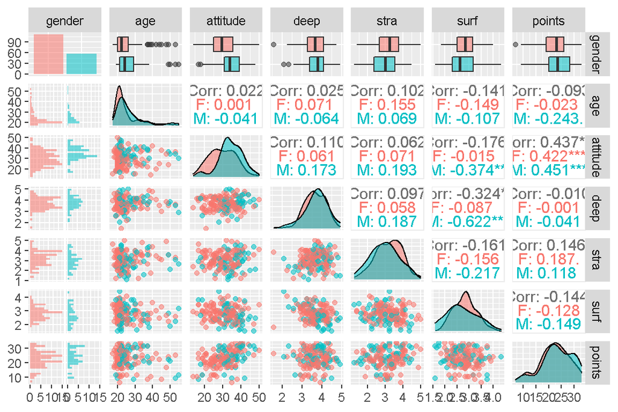

```r
library(ggplot2)

plot1 <- ggpairs(lrndata, mapping = aes(col = gender, alpha = 0.3), lower = list(combo = wrap("facethist", bins = 20)))
plot1
```

Below you can see summaries of variables in the data. For the numeric variables it shows the minimum, maximum, median, mean and cutpoint values for first quartile (25%) and third Quartile (75%). Further inspecting gender variable, we can see there are 110 females and 56 males in the data.

```r
summary(lrndata)
```

```
##     gender               age           attitude          deep
##  Length:166         Min.   :17.00   Min.   :14.00   Min.   :1.583
##  Class :character   1st Qu.:21.00   1st Qu.:26.00   1st Qu.:3.333
##  Mode  :character   Median :22.00   Median :32.00   Median :3.667
##                     Mean   :25.51   Mean   :31.43   Mean   :3.680
##                     3rd Qu.:27.00   3rd Qu.:37.00   3rd Qu.:4.083
##                     Max.   :55.00   Max.   :50.00   Max.   :4.917
##       stra            surf           points
##  Min.   :1.250   Min.   :1.583   Min.   : 7.00
##  1st Qu.:2.625   1st Qu.:2.417   1st Qu.:19.00
##  Median :3.188   Median :2.833   Median :23.00
##  Mean   :3.121   Mean   :2.787   Mean   :22.72
##  3rd Qu.:3.625   3rd Qu.:3.167   3rd Qu.:27.75
##  Max.   :5.000   Max.   :4.333   Max.   :33.00
```

```r
table (lrndata$gender)
```

```
##
##   F   M
## 110  56
```

### Step 3

For the regression model, I use students’ attitudes toward statistics, strategic learning approach and gender to explain students’ exam points. Below you can the summaries of two fitted models; model 1 with all three explanatory variables and model 2 only with the explanatory variable (attitude toward statistics) that has a statistically significant relationship with the target variable. The other two explanatory variables, strategic learning approach and gender, did not have a statistically significant relationship with exam points, and they were removed from the model and the model 2 was fitted again without them.

The regression model 1 consists of a set of three explanatory variables. The model output gives a summary of the model residuals which correspond to the prediction errors of the model. The coefficient part shows the estimates of the parameters in the model. The estimates tell us that the effect of attitudes on exam points is 0.35 with a standard error of 0.06. The parameter estimate tells us that a one unit-unit change in the attitude variable produces a 0.35-unit increase in exam points when all the other explanatory variables is being held constant. The t value corresponds to a statistical test of a null hypothesis so it tests the significance of the coefficient. T value is obtained by dividing the regression parameter estimate by its standard error. P value for the attitude variable is highly significant so we can conclude that there is a statistical relationship between exam points and attitudes toward statistics.

Same interpretation goes with the stra variable: its parameter estimate tells us that a one unit-unit change in the stra variable produces a 0.89-unit increase in exam points when all the other explanatory variables is being held constant. The P value for the stra variable is not significant so we cannot say anything certain about the statistical relationship between exam points and strategic learning approach.

The coefficient of gender indicates that males have -0.22 lower exam points than females when other explanatory variables are controlled. Also, the P value for the gender variable is not significant so there is no evidence of the statistical relationship between exam points and gender.

```r
# fit a linear model
model1 <- lm(points ~ attitude + stra + gender, data = lrndata)

# print out a summary of the model
summary(model1)
```

```
##
## Call:
## lm(formula = points ~ attitude + stra + gender, data = lrndata)
##
## Residuals:
##      Min       1Q   Median       3Q      Max
## -17.7179  -3.3285   0.5343   3.7412  10.9007
##
## Coefficients:
##             Estimate Std. Error t value Pr(>|t|)
## (Intercept)  8.97982    2.40303   3.737 0.000258 ***
## attitude     0.35100    0.05956   5.893 2.13e-08 ***
## stra         0.89107    0.54409   1.638 0.103419
## genderM     -0.22362    0.92477  -0.242 0.809231
## ---
## Signif. codes:  0 '***' 0.001 '**' 0.01 '*' 0.05 '.' 0.1 ' ' 1
##
## Residual standard error: 5.304 on 162 degrees of freedom
## Multiple R-squared:  0.2051, Adjusted R-squared:  0.1904
## F-statistic: 13.93 on 3 and 162 DF,  p-value: 3.982e-08
```

```r
# fit a linear model
model2 <- lm(points ~ attitude, data = lrndata)

# print out a summary of the model
summary(model2)
```

```
##
## Call:
## lm(formula = points ~ attitude, data = lrndata)
##
## Residuals:
##      Min       1Q   Median       3Q      Max
## -16.9763  -3.2119   0.4339   4.1534  10.6645
##
## Coefficients:
##             Estimate Std. Error t value Pr(>|t|)
## (Intercept) 11.63715    1.83035   6.358 1.95e-09 ***
## attitude     0.35255    0.05674   6.214 4.12e-09 ***
## ---
## Signif. codes:  0 '***' 0.001 '**' 0.01 '*' 0.05 '.' 0.1 ' ' 1
##
## Residual standard error: 5.32 on 164 degrees of freedom
## Multiple R-squared:  0.1906, Adjusted R-squared:  0.1856
## F-statistic: 38.61 on 1 and 164 DF,  p-value: 4.119e-09
```

### Step 4

Using a summary of your fitted model, explain the relationship between the chosen explanatory variables and the target variable (interpret the model parameters). Explain and interpret the multiple R squared of the model. (0-3 points)

The summary of the model 2 tell us that the effect of attitudes on exam points is 0.35 with a standard error of 0.06 and we can see there is no change in the parameters between models 1 and 2. Again, a one unit-unit change in the attitude variable produces a 0.35-unit increase in exam points. P value for the attitude variable is highly significant, p < 0.000.

The multiple R squared of the model tells us how well the model fits the data. It tells us that variation in attitudes explains 19.1% of the variance in exam points (multiple R-squared gets a value 0.1906). With only one explanatory variable, the multiple R-squared is the square of the correlation coefficient between exam points and attitudes.

### Step 5

I produced the following diagnostic plots for the model 2: Residuals vs Fitted values, Normal QQ-plot and Residuals vs Leverage. With these plots it is possible to check the assumptions of linear regression models: (1) the errors are normally distributed, (2) the errors are not correlated, (3) the errors have constant variance, and (4) the size of a given error does not depend on the explanatory variables.

To check the constant variance of errors, we look at the residuals vs Fitted values plot, which is scatter plot of residuals and model predictions. There are no patterns in the scatter plot so we can say that the model errors have constant variance.

To check the normality of the errors we look at the QQ-plot of the residuals. The residuals seem to fall onto the line quite well which means that the errors of the model fit to the normality assumption.

To check that the size of a given error is not dependent on the explanatory variables, we look at the residuals vs leverage plot which measures the impact of a single observation on the model. We can see that any of the observations is not specifically pulling the regression line upwards or downwards. We can say that none of the observations has an unusually high impact on the size of the given errors.

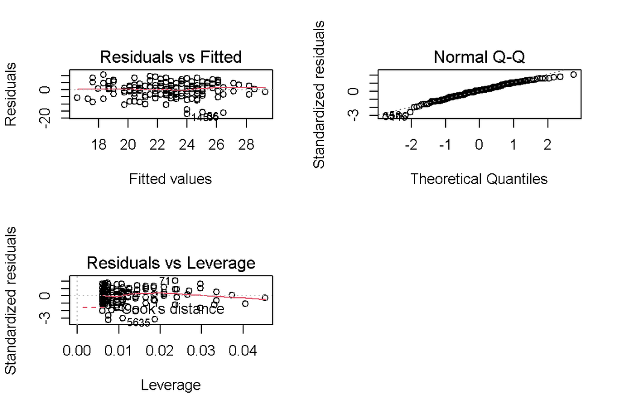

```r
par(mfrow = c(2,2))
plot(model2, which = c(1,2,5))
```

## Logistic Regression

data source: https://archive.ics.uci.edu/ml/datasets/Student+Performance

```r
date()
```

```
## [1] "Mon Dec 13 11:23:59 2021"
```

### Steps 1 & 2

I created a new R Markdown file named ‘chapter3.Rmd’ to perform this week’s analyses in it. I read the joined student alcohol consumption data into R from your local folder and printed out the names of the variables in the data.

This data includes information on student achievement in secondary education of two Portuguese schools. The data attributes include student grades (G1 = average first period grade of maths and Portuguese, G2 = average second period grade of maths and Portuguese, G3 = average final grade of maths and Portuguese, G1-3.p = Portuguese grades, G1-3.m = maths grades), demographic (e.g. sex = gender, age, famsize = family size, Medu = mother’s education, Fedu = father’s education), social and school related features (e.g. romantic = with a romantic relationship, absences = average number of school absences, alc_use = weekly alcohol use, high_use = high level of weekly alcohol use), and it was collected by using school reports and questionnaires. The dataset combines two datasets that provide data regarding the performance in mathematics and Portuguese language. More information about the variables in the dataset can be found here: https://archive.ics.uci.edu/ml/datasets/Student+Performance.

```r
setwd("~/Git/IODS-project")
pormath <- read.table ("C:/Users/irisp/Documents/Git/IODS-project/data/pormath.csv")
colnames(pormath)
```

```
##  [1] "school"     "sex"        "age"        "address"    "famsize"
##  [6] "Pstatus"    "Medu"       "Fedu"       "Mjob"       "Fjob"
## [11] "reason"     "guardian"   "traveltime" "studytime"  "schoolsup"
## [16] "famsup"     "activities" "nursery"    "higher"     "internet"
## [21] "romantic"   "famrel"     "freetime"   "goout"      "Dalc"
## [26] "Walc"       "health"     "n"          "id.p"       "id.m"
## [31] "failures"   "paid"       "absences"   "G1"         "G2"
## [36] "G3"         "failures.p" "paid.p"     "absences.p" "G1.p"
## [41] "G2.p"       "G3.p"       "failures.m" "paid.m"     "absences.m"
## [46] "G1.m"       "G2.m"       "G3.m"       "alc_use"    "high_use"
```

### Step 3

The purpose of this analysis is to study the relationships between high/low alcohol consumption and the following 4 variables in the data: quality of family relationships (famrel), average number of school absences (absences), gender (sex) and going out with friends (goout).

My personal hypotheses about the relationships of those variables with alcohol consumption: 1. Males have higher probability of consuming more alcohol than females. 2. Higher number of average of school absences increases the probability of consuming more alcohol. 3. Better quality family relationships decrease the probability of consuming more alcohol. 4. The more students go out with their friends, the higher probability they have of consuming more alcohol.

### Step 4

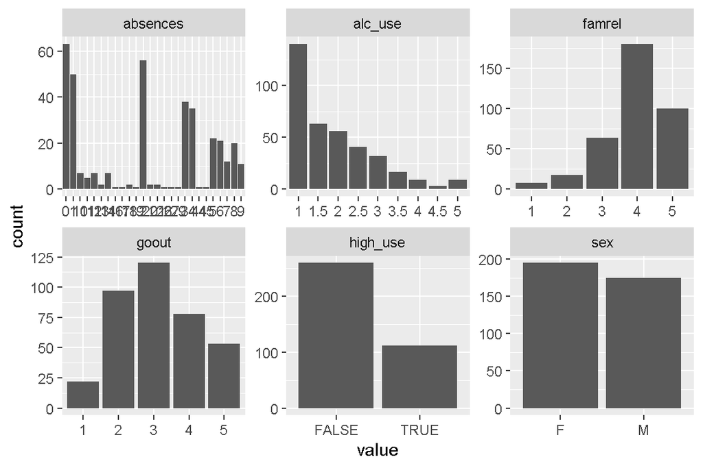

```r
# access the tidyverse libraries tidyr, dplyr, ggplot2
library(tidyr); library(dplyr); library(ggplot2); library(GGally)
# A bar plot of each variable
gather(pormath[c(2,22,24,33,49,50)]) %>% ggplot(aes(value)) + facet_wrap("key", scales = "free") + geom_bar()
```

Below is a graphical overview of the data which shows (1) boxplots and scatterplots of each variable pair visualized on left and upper side, (2) variable distributions on the diagonal and (3) Pearson correlation value and significance displayed on the right side of the plot. The colours of the overview represent the values of the gender variable (females and males).

The box plots show the gender wise distribution of the chosen variables and their lower and higher quartiles and median. Red colour represents female gender and blue colour male gender. The boxplot also show some dots that are outliers or extreme values.

The distributions of the variables show us the same distributions as the histograms above but now we can see the distributions separately for males and females.

The absences and going out variables correlate significantly positively with the students’ alcohol use. Alcohol use correlates significantly negatively with males’ quality of family relationship. Based on these explorations, we can compare the results to my previously stated hypotheses. It seems that all of my hypotheses find support from these results: male consume more alcohol, higher number of average of school absences increases alcohol consumption, better quality family relationships decrease alcohol consumption of males and the more students go out with their friends, the more they consume alcohol.

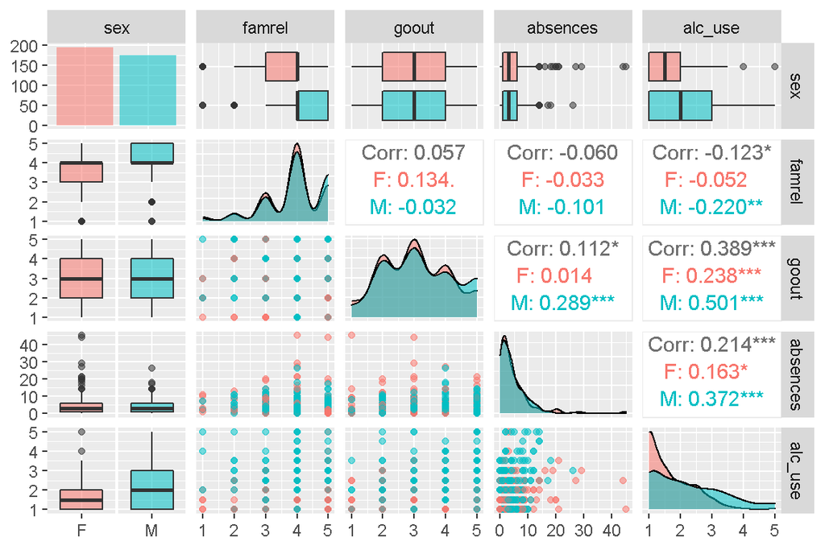

```r
plot1 <- ggpairs(pormath, mapping = aes(col = sex, alpha = 0.3),
                 columns = c(2,22,24,33,49), lower = list(combo = wrap("box")))
plot1
```

Similar patterns and relationships can be also detected from the cross tabulation tables below.

```r
# Cross tabulation: summary statistics by group
pormath %>% group_by(sex, high_use) %>% summarise(count = n())
```

```
## # A tibble: 4 x 3
## # Groups:   sex [2]
##   sex   high_use count
##   <chr> <lgl>    <int>
## 1 F     FALSE      154
## 2 F     TRUE        41
## 3 M     FALSE      105
## 4 M     TRUE        70
```

```r
pormath %>% group_by(absences, high_use) %>% summarise(count = n())
```

```
## # A tibble: 43 x 3
## # Groups:   absences [26]
##    absences high_use count
##       <int> <lgl>    <int>
##  1        0 FALSE       50
##  2        0 TRUE        13
##  3        1 FALSE       37
##  4        1 TRUE        13
##  5        2 FALSE       40
##  6        2 TRUE        16
##  7        3 FALSE       31
##  8        3 TRUE         7
##  9        4 FALSE       24
## 10        4 TRUE        11
## # ... with 33 more rows
```

```r
pormath %>% group_by(famrel, high_use, sex) %>% summarise(count = n())
```

```
## # A tibble: 19 x 4
## # Groups:   famrel, high_use [10]
##    famrel high_use sex   count
##     <int> <lgl>    <chr> <int>
##  1      1 FALSE    F         5
##  2      1 FALSE    M         1
##  3      1 TRUE     M         2
##  4      2 FALSE    F         6
##  5      2 FALSE    M         3
##  6      2 TRUE     F         3
##  7      2 TRUE     M         6
##  8      3 FALSE    F        24
##  9      3 FALSE    M        15
## 10      3 TRUE     F        12
## 11      3 TRUE     M        13
## 12      4 FALSE    F        80
## 13      4 FALSE    M        48
## 14      4 TRUE     F        19
## 15      4 TRUE     M        33
## 16      5 FALSE    F        39
## 17      5 FALSE    M        38
## 18      5 TRUE     F         7
## 19      5 TRUE     M        16
```

```r
pormath %>% group_by(goout, high_use) %>% summarise(count = n())
```

```
## # A tibble: 10 x 3
## # Groups:   goout [5]
##    goout high_use count
##    <int> <lgl>    <int>
##  1     1 FALSE       19
##  2     1 TRUE         3
##  3     2 FALSE       82
##  4     2 TRUE        15
##  5     3 FALSE       97
##  6     3 TRUE        23
##  7     4 FALSE       40
##  8     4 TRUE        38
##  9     5 FALSE       21
## 10     5 TRUE        32
```

### Step 5

Second, I use logistic regression to statistically explore the relationship between my chosen variables and the binary high/low alcohol consumption variable as the target variable. From the summary of the model m, we can see that all the explanatory variables are highly significant and so we can conclude that there is a statistical relationship between high alcohol use and all the explanatory variables. We can also see from the logistic regression coefficients that male students are more likely to have high alcohol consumption than females, having more absences at school and going out with friends more increase high alcohol consumption and having good quality family relationships decrease high alcohol consumption of students.

```r
m <- glm(high_use ~ sex + absences + famrel + goout, data = pormath, family = "binomial")

# print out a summary of the model
summary(m)
```

```
##
## Call:
## glm(formula = high_use ~ sex + absences + famrel + goout, family = "binomial",
##     data = pormath)
##
## Deviance Residuals:
##     Min       1Q   Median       3Q      Max
## -1.7082  -0.7909  -0.5005   0.7441   2.5673
##
## Coefficients:
##             Estimate Std. Error z value Pr(>|z|)
## (Intercept) -2.71101    0.66639  -4.068 4.74e-05 ***
## sexM         1.07940    0.26449   4.081 4.48e-05 ***
## absences     0.08218    0.02227   3.691 0.000224 ***
## famrel      -0.41726    0.14164  -2.946 0.003219 **
## goout        0.76974    0.12445   6.185 6.20e-10 ***
## ---
## Signif. codes:  0 '***' 0.001 '**' 0.01 '*' 0.05 '.' 0.1 ' ' 1
##
## (Dispersion parameter for binomial family taken to be 1)
##
##     Null deviance: 452.04  on 369  degrees of freedom
## Residual deviance: 365.31  on 365  degrees of freedom
## AIC: 375.31
##
## Number of Fisher Scoring iterations: 4
```

When odds ratio is less than 1.00, we need to substract the odds ratio from 1.00 to find the decrease in odds ratio. Thus, better quality family relationships decrease the odds of having high alcohol consumption by (1.00-0.65)x100 = 35%.

Also the odds ratios support the hypotheses that I made earlier. We can say that based of the results of the logistic regression: 1. Males have higher probability of consuming more alcohol than females, 2. Higher number of average of school absences increases the probability of consuming more alcohol, 3. Better quality family relationships decrease the probability of consuming more alcohol, and 4. The more students go out with their friends, the higher probability they have of consuming more alcohol.

```r
# compute odds ratios (OR)
OR <- coef(m) %>% exp

# compute confidence intervals (CI)
CI <- confint(m) %>% exp
# print out the odds ratios with their confidence intervals
cbind(OR, CI)
```

```
##                     OR      2.5 %    97.5 %
## (Intercept) 0.06646973 0.01731071 0.2381125
## sexM        2.94291184 1.76506498 4.9902818
## absences    1.08565191 1.04010669 1.1366801
## famrel      0.65884637 0.49727062 0.8681721
## goout       2.15919501 1.70320000 2.7776306
```

### Step 6

Using all the variables which, according to my logistic regression model, had a statistical relationship with high/low alcohol consumption, I explore the predictive power of my model. Below you can see a 2x2 cross tabulation of predictions versus the actual values. It seems that the model has correctly predicted 243 as low and 53 as high alcohol users and wrongly predicted 58 cases as low alcohol users and 16 cases as high alcohol users.

```r
# predict() the probability of high_use
probabilities <- predict(m, type = "response")

# add the predicted probabilities to the data
pormath <- mutate(pormath, probability = probabilities)

# use the probabilities to make a prediction of high_use
pormath <- mutate(pormath, prediction = pormath$probability > 0.5)

# tabulate the target variable versus the predictions
table(high_use = pormath$high_use, prediction = pormath$probability > 0.5)
```

```
##         prediction
## high_use FALSE TRUE
##    FALSE   243   16
##    TRUE     58   53
```

Below is a graphic visualizing both the actual values and the predictions.

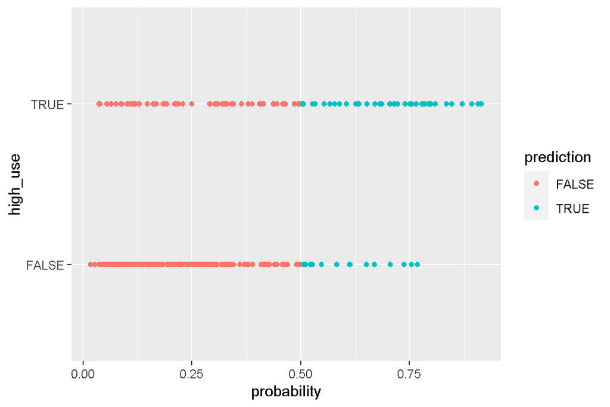

```r
# initialize a plot of 'high_use' versus 'probability'
g <- ggplot(pormath, aes(x = probability, y = high_use, col = prediction))
g + geom_point()
```

```r
# define a loss function (mean prediction error)
loss_func <- function(class, prob) {
  n_wrong <- abs(class - prob) > 0.5
  mean(n_wrong)
}

# call loss_func to compute the average number of wrong predictions in the data
#Execute the call to the loss function with prob = 0, meaning you define the probability of high_use as zero for each individual
loss_func(class = pormath$high_use, prob = 0)
```

```
## [1] 0.3
```

### Step 7

I performed 10-fold cross-validation on the model m. My model seems to have better test set performance (smaller prediction error using 10-fold cross-validation) compared to the model introduced in DataCamp (which had about 0.26 error). My model has 0.21 prediction error which is smaller than the DataCamp training model. Cross-validation is a method of testing a predictive model on unseen data and it can also be used to compare different models. The lower the value is, the better the model performance and the actual predictive power of the model.

```r
# K-fold cross-validation
library(boot)

cv <- cv.glm(data = pormath, cost = loss_func, glmfit = m, K = 10)

# average number of wrong predictions in the cross validation
cv$delta[1]
```

```
## [1] 0.2081081
```

## Clustering and Classification

This week I learned new techniques of data clustering and classification. With the data already saved into R, I performed and interpreted k-means clustering and linear discriminant analysis. All the R codes, interpretations and explanations of the analysis exercises are found below.

data source: the Boston data from the MASS package

```r
date()
```

```
## [1] "Mon Dec 13 11:24:07 2021"
```

### Step 1:

Boston dataset contains 506 rows and 14 columns (506 observations, and 14 variables) and describes housing Values in Suburbs of Boston. Data consists of variables such as per capita crime rate by town (variable crim), average number of rooms per dwelling (variable rm), the proportion of blacks by town (variable black) and median value of owner-occupied homes in $1000s (variable medv).

More information about the variables in the Boston dataset can be found here: https://stat.ethz.ch/R-manual/R-devel/library/MASS/html/Boston.html.

```r
library(MASS)
# load the data
data("Boston")
str(Boston)
```

```
## 'data.frame':    506 obs. of  14 variables:
##  $ crim   : num  0.00632 0.02731 0.02729 0.03237 0.06905 ...
##  $ zn     : num  18 0 0 0 0 0 12.5 12.5 12.5 12.5 ...
##  $ indus  : num  2.31 7.07 7.07 2.18 2.18 2.18 7.87 7.87 7.87 7.87 ...
##  $ chas   : int  0 0 0 0 0 0 0 0 0 0 ...
##  $ nox    : num  0.538 0.469 0.469 0.458 0.458 0.458 0.524 0.524 0.524 0.524 ...
##  $ rm     : num  6.58 6.42 7.18 7 7.15 ...
##  $ age    : num  65.2 78.9 61.1 45.8 54.2 58.7 66.6 96.1 100 85.9 ...
##  $ dis    : num  4.09 4.97 4.97 6.06 6.06 ...
##  $ rad    : int  1 2 2 3 3 3 5 5 5 5 ...
##  $ tax    : num  296 242 242 222 222 222 311 311 311 311 ...
##  $ ptratio: num  15.3 17.8 17.8 18.7 18.7 18.7 15.2 15.2 15.2 15.2 ...
##  $ black  : num  397 397 393 395 397 ...
##  $ lstat  : num  4.98 9.14 4.03 2.94 5.33 ...
##  $ medv   : num  24 21.6 34.7 33.4 36.2 28.7 22.9 27.1 16.5 18.9 ...
```

```r
dim(Boston)
```

```
## [1] 506  14
```

### Step 2

First, we look at the summaries of the variables in the Boston data. We see that the data contains mostly numeric variables with the exception of rad which is an integer index variable and chas which is a binary variable. .

```r
# access the following packages
library(tidyr); library(dplyr); library(ggplot2); library(GGally); library(corrplot)
summary(Boston)
```

```
##       crim                zn             indus            chas
##  Min.   : 0.00632   Min.   :  0.00   Min.   : 0.46   Min.   :0.00000
##  1st Qu.: 0.08205   1st Qu.:  0.00   1st Qu.: 5.19   1st Qu.:0.00000
##  Median : 0.25651   Median :  0.00   Median : 9.69   Median :0.00000
##  Mean   : 3.61352   Mean   : 11.36   Mean   :11.14   Mean   :0.06917
##  3rd Qu.: 3.67708   3rd Qu.: 12.50   3rd Qu.:18.10   3rd Qu.:0.00000
##  Max.   :88.97620   Max.   :100.00   Max.   :27.74   Max.   :1.00000
##       nox               rm             age              dis
##  Min.   :0.3850   Min.   :3.561   Min.   :  2.90   Min.   : 1.130
##  1st Qu.:0.4490   1st Qu.:5.886   1st Qu.: 45.02   1st Qu.: 2.100
##  Median :0.5380   Median :6.208   Median : 77.50   Median : 3.207
##  Mean   :0.5547   Mean   :6.285   Mean   : 68.57   Mean   : 3.795
##  3rd Qu.:0.6240   3rd Qu.:6.623   3rd Qu.: 94.08   3rd Qu.: 5.188
##  Max.   :0.8710   Max.   :8.780   Max.   :100.00   Max.   :12.127
##       rad              tax           ptratio          black
##  Min.   : 1.000   Min.   :187.0   Min.   :12.60   Min.   :  0.32
##  1st Qu.: 4.000   1st Qu.:279.0   1st Qu.:17.40   1st Qu.:375.38
##  Median : 5.000   Median :330.0   Median :19.05   Median :391.44
##  Mean   : 9.549   Mean   :408.2   Mean   :18.46   Mean   :356.67
##  3rd Qu.:24.000   3rd Qu.:666.0   3rd Qu.:20.20   3rd Qu.:396.23
##  Max.   :24.000   Max.   :711.0   Max.   :22.00   Max.   :396.90
##      lstat            medv
##  Min.   : 1.73   Min.   : 5.00
##  1st Qu.: 6.95   1st Qu.:17.02
##  Median :11.36   Median :21.20
##  Mean   :12.65   Mean   :22.53
##  3rd Qu.:16.95   3rd Qu.:25.00
##  Max.   :37.97   Max.   :50.00
```

Below we can see a graphical overview of histograms of all the variables in the Boston data, combined with the density curves.

- age variable tells us the proportion of owner-occupied units built prior to 1940. This variable is slightly skewed towards right which mean that there is a high proportion of owner occupied units built prior to 1940.
- Also variables black is skewed towards right which means that there is a high proportion of blacks in town.
- Variables crim and zn are heavily skewed towards left which means that there is low proportion of per capita crime rate by town and residential land zoned for lots over 25,000 sq.ft.
- Also the variables dis and lstat are skewed towards right which tells us that the mean of distances from the Boston suburbs to five Boston employment centres is relatively low, and a low proportion of the population in the Boston suburbs have lower status.
- Variable chas tells us that there are more suburbs that do not bound the Charles River than which do.
- Variables medv (median value of owner-occupied homes in $1000s) and rm (average number of rooms per dwelling) are normally distributed. Also, variables tax (full-value property-tax rate per $10,000) and rad (index of accessibility to radial highways) would have normal distribution but both of them have outlier variables at the right end of the distribution.
- nox variable is slightly skewed towards left which means that there is a lower proportion of nitrogen oxides concentration in the Boston suburbs.
- ptratio variable seems to have a slightly skewed distribution towards right which tells us that there is a higher proportion of pupil-teacher ratio by town.
- indus variable has two curves in its distribution which means that the proportion of non-retail business acres per town is either low or high.

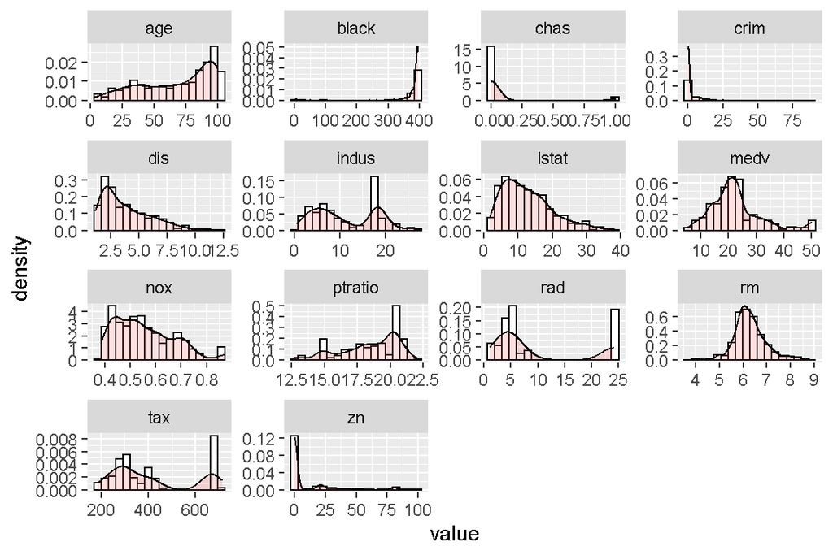

```r
# A bar plot of each variable
gather(Boston) %>% ggplot(aes(value)) + facet_wrap("key", scales = "free") +
  geom_histogram(aes(y = ..density..),
                   colour="black", fill="white", bins = 18,) +
  geom_density(alpha = 0.2, fill = "#FF6666")
```

Below we can see a graphical overview of the correlations of the all the variables in the Boston data.

We can see high positive correlations between the following variables:

- medv and rm, meaning that the higher the median value of owner-occupied homes is, the higher the average number of rooms per dwelling is.
- lstat and age, nox and indus, meaning that the higher the lower the proportion of the lower status population is, the higher the age of the buildings, the nitrogen oxides concentration and the proportion of non-retail business acres per town are.
- tax and rad, nox, indus and crim, meaning that the higher the full-value property-tax rate is, the better the accessibility to radial highways is and the higher the nitrogen oxides concentration, the proportion of non-retail business acres per town and per capita crime rate are.
- rad and nox, indus and crim, meaning that the better the accessibility to radial highways is, the higher the nitrogen oxides concentration, proportion of non-retail business acres and per capita crime rate are.
- dis and zn, meaning that the longer the distance from the Boston employment centres is, the higher the proportion of residential land zoned for lots over 25,000 sq.ft is.
- age and nox and indus, meaning that the older the age of the buildings, the higher the nitrogen oxides concentration and the proportion of non-retail business acres per town are.
- nox and indus, meaning that the higher the nitrogen oxides concentration, the higher the proportion of non-retail business acres per town is.

We can see high negative correlations between the following variables:

- dis and age, nox and indus, meaning that the longer the distance from the Boston employment centres is, the lower the age of the buildings, the nitrogen oxides concentration and the proportion of non-retail business acres per town are.
- medv and lstat, meaning that the higher the median value of owner-occupied homes is, the lower the proportion of the lower status population is.
- lstat and rm, meaning that the higher the lower the proportion of the lower status population is, the lower the average number of rooms per dwelling is.

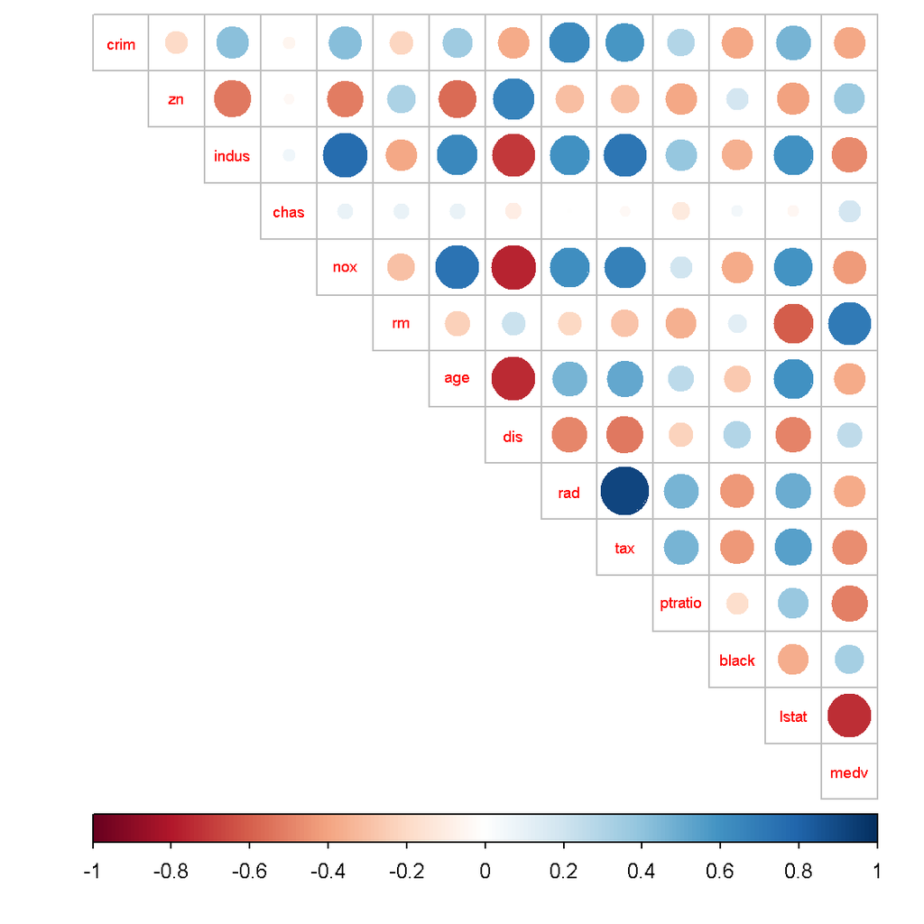

```r
# calculate the correlation matrix and round it
cor_matrix<-cor(Boston) %>% round(digits = 2)

# visualize the correlation matrix
corrplot(cor_matrix, method="circle", type="upper", cl.pos="b", tl.pos="d", tl.cex = 0.6)
```

### Step 3

Standardize the dataset and print out summaries of the scaled data. Now, we can see that compared to the non-standardized dataset, all the variables in the scaled dataset have been rescaled to have a mean of zero and a standard deviation of one.

```r
#standardizing Boston data
boston_scaled <- scale(Boston)

# summaries of the scaled variables
summary(boston_scaled)
```

```
##       crim                 zn               indus              chas
##  Min.   :-0.419367   Min.   :-0.48724   Min.   :-1.5563   Min.   :-0.2723
##  1st Qu.:-0.410563   1st Qu.:-0.48724   1st Qu.:-0.8668   1st Qu.:-0.2723
##  Median :-0.390280   Median :-0.48724   Median :-0.2109   Median :-0.2723
##  Mean   : 0.000000   Mean   : 0.00000   Mean   : 0.0000   Mean   : 0.0000
##  3rd Qu.: 0.007389   3rd Qu.: 0.04872   3rd Qu.: 1.0150   3rd Qu.:-0.2723
##  Max.   : 9.924110   Max.   : 3.80047   Max.   : 2.4202   Max.   : 3.6648
##       nox                rm               age               dis
##  Min.   :-1.4644   Min.   :-3.8764   Min.   :-2.3331   Min.   :-1.2658
##  1st Qu.:-0.9121   1st Qu.:-0.5681   1st Qu.:-0.8366   1st Qu.:-0.8049
##  Median :-0.1441   Median :-0.1084   Median : 0.3171   Median :-0.2790
##  Mean   : 0.0000   Mean   : 0.0000   Mean   : 0.0000   Mean   : 0.0000
##  3rd Qu.: 0.5981   3rd Qu.: 0.4823   3rd Qu.: 0.9059   3rd Qu.: 0.6617
##  Max.   : 2.7296   Max.   : 3.5515   Max.   : 1.1164   Max.   : 3.9566
##       rad               tax             ptratio            black
##  Min.   :-0.9819   Min.   :-1.3127   Min.   :-2.7047   Min.   :-3.9033
##  1st Qu.:-0.6373   1st Qu.:-0.7668   1st Qu.:-0.4876   1st Qu.: 0.2049
##  Median :-0.5225   Median :-0.4642   Median : 0.2746   Median : 0.3808
##  Mean   : 0.0000   Mean   : 0.0000   Mean   : 0.0000   Mean   : 0.0000
##  3rd Qu.: 1.6596   3rd Qu.: 1.5294   3rd Qu.: 0.8058   3rd Qu.: 0.4332
##  Max.   : 1.6596   Max.   : 1.7964   Max.   : 1.6372   Max.   : 0.4406
##      lstat              medv
##  Min.   :-1.5296   Min.   :-1.9063
##  1st Qu.:-0.7986   1st Qu.:-0.5989
##  Median :-0.1811   Median :-0.1449
##  Mean   : 0.0000   Mean   : 0.0000
##  3rd Qu.: 0.6024   3rd Qu.: 0.2683
##  Max.   : 3.5453   Max.   : 2.9865
```

```r
# class of the boston_scaled object
class(boston_scaled)
```

```
## [1] "matrix" "array"
```

```r
# change the object to data frame
boston_scaled <- as.data.frame(boston_scaled)
```

Next, I created a categorical variable of the crime rate in the Boston dataset (from the scaled crime rate) and used quantiles as the break points in the categorical variable. In addition, I dropoed the old crime rate variable from the dataset.

```r
# summary of the scaled crime rate
summary(boston_scaled$crim)
```

```
##      Min.   1st Qu.    Median      Mean   3rd Qu.      Max.
## -0.419367 -0.410563 -0.390280  0.000000  0.007389  9.924110
```

```r
# create a quantile vector of crim and print it
bins <- quantile(boston_scaled$crim)
bins
```

```
##           0%          25%          50%          75%         100%
## -0.419366929 -0.410563278 -0.390280295  0.007389247  9.924109610
```

```r
# create a categorical variable 'crime'
crime <- cut(boston_scaled$crim, breaks = bins, include.lowest = TRUE, label=c("low", "med_low", "med_high", "high"))

# look at the table of the new factor crime
table(crime)
```

```
## crime
##      low  med_low med_high     high
##      127      126      126      127
```

```r
# remove original crim from the dataset
boston_scaled <- dplyr::select(boston_scaled, -crim)

# add the new categorical value to scaled data
boston_scaled <- data.frame(boston_scaled, crime)
```

Here, we divide the Boston dataset into train and test sets, so that 80% of the data belongs to the train set.

```r
# number of rows in the Boston dataset
n <- nrow(boston_scaled)

# choose randomly 80% of the rows
ind <- sample(n,  size = n * 0.8)

# create train set
train <- boston_scaled[ind,]

# create test set
test <- boston_scaled[-ind,]
```

### Step 4

Below, I perform a Linear Discriminant analysis which is a classification (and dimension reduction) method. It finds the (linear) combination of the variables that separate the classes of the target variable which can be binary or multiclass variable.

```r
# linear discriminant analysis
lda.fit <- lda(crime ~ ., data = train)

# print the lda.fit object
lda.fit
```

```
## Call:
## lda(crime ~ ., data = train)
##
## Prior probabilities of groups:
##       low   med_low  med_high      high
## 0.2524752 0.2524752 0.2549505 0.2400990
##
## Group means:
##                  zn      indus        chas        nox         rm        age
## low       1.0048421 -0.8755501 -0.11793298 -0.8830387  0.4159559 -0.8740088
## med_low  -0.1007154 -0.2786849 -0.04073494 -0.5741345 -0.1498139 -0.3073087
## med_high -0.3690158  0.1536644  0.10991367  0.3691044  0.1068910  0.4036395
## high     -0.4872402  1.0172187 -0.02879709  1.0535087 -0.3954513  0.8033265
##                 dis        rad        tax     ptratio      black       lstat
## low       0.9247458 -0.6970063 -0.7347651 -0.46310284  0.3777835 -0.76351099
## med_low   0.3602313 -0.5472552 -0.4466457 -0.05236932  0.3125252 -0.10404128
## med_high -0.3711166 -0.4154428 -0.3029166 -0.23821744  0.1027009 -0.01331764
## high     -0.8428043  1.6371072  1.5133254  0.77958792 -0.7416775  0.82342557
##                 medv
## low       0.48816917
## med_low  -0.02648558
## med_high  0.17303985
## high     -0.71210471
##
## Coefficients of linear discriminants:
##                 LD1         LD2         LD3
## zn       0.10790053  0.71181172 -0.97639563
## indus   -0.06402572 -0.06338737  0.19642532
## chas    -0.09930402 -0.02335660  0.07973857
## nox      0.39949035 -0.78007908 -1.38780190
## rm      -0.11835883 -0.06789086 -0.15784980
## age      0.22176821 -0.27512708 -0.11550199
## dis     -0.13391739 -0.17654612  0.16309182
## rad      3.20274263  1.01113462 -0.14807486
## tax      0.01171418 -0.12599303  0.71275799
## ptratio  0.12773872 -0.04265130 -0.33766351
## black   -0.13906075  0.03954469  0.09870047
## lstat    0.21287993 -0.25833437  0.43284405
## medv     0.19024051 -0.46579626 -0.15164383
##
## Proportion of trace:
##    LD1    LD2    LD3
## 0.9477 0.0376 0.0147
```

LDA can be visualized with a biplot which is done below:

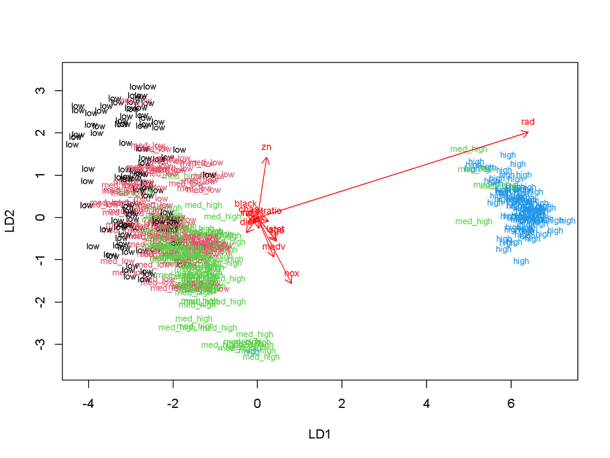

```r
# the function for lda biplot arrows
lda.arrows <- function(x, myscale = 1, arrow_heads = 0.1, color = "red", tex = 0.75, choices = c(1,2)){
  heads <- coef(x)
  arrows(x0 = 0, y0 = 0,
         x1 = myscale * heads[,choices[1]],
         y1 = myscale * heads[,choices[2]], col=color, length = arrow_heads)
  text(myscale * heads[,choices], labels = row.names(heads),
       cex = tex, col=color, pos=3)
}

# target classes as numeric
classes <- as.numeric(train$crime)

# plot the lda results
plot(lda.fit, dimen = 2, col = classes, pch = classes)
lda.arrows(lda.fit, myscale = 2.0)
```

### Step 5

Here, first, I save the crime categories from the test set and then remove the categorical crime variable from the test dataset. Second, I predict the classes with the LDA model on the test data and cross tabulate the results with the crime categories from the test set.

```r
# save the correct classes from test data
correct_classes <- test$crime

# remove the crime variable from test data
test <- dplyr::select(test, -crime)

# predict classes with test data
lda.pred <- predict(lda.fit, newdata = test)

# cross tabulate the results
table(correct = correct_classes, predicted = lda.pred$class)
```

```
##           predicted
## correct    low med_low med_high high
##   low       13      11        1    0
##   med_low    6      13        5    0
##   med_high   0       3       19    1
##   high       0       0        0   30
```

### Step 6

```r
# reload the data
data("Boston")

#standardizing Boston data
boston_scaled <- scale(Boston)

# change the object to data frame
boston_scaled <- as.data.frame(boston_scaled)

# euclidean distance matrix
dist_eu <- dist(Boston)

# look at the summary of the distances
summary(dist_eu)
```

```
##    Min. 1st Qu.  Median    Mean 3rd Qu.    Max.
##   1.119  85.624 170.539 226.315 371.950 626.047
```

Next, we run k-means algorithm on the dataset. K-means is the most known clustering method. It is an unsupervised method, that assigns observations to groups or clusters based on similarity of the objects.

```r
km <-kmeans(Boston, centers = 3)
```

K-means needs the number of clusters set in advance and the optimal number of clusters can be determined by looking at how the total of within cluster sum of squares (WCSS) behaves when the number of cluster changes. Plotting the number of clusters and the total WCSS, the optimal number of clusters is when the total WCSS drops radically.

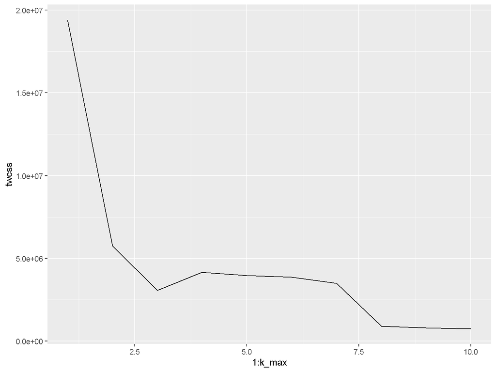

```r
set.seed(123)

# determine the number of clusters
k_max <- 10

# calculate the total within sum of squares
twcss <- sapply(1:k_max, function(k){kmeans(Boston, k)$tot.withinss})

# visualize the results
qplot(x = 1:k_max, y = twcss, geom = 'line')
```

When investigating the optimal number of clusters, we see that there is a radical drop in the total WCSS when the number of clusters is 2. I run k-means algorithm again setting the number of clusters as 2. From the visualization of the clusters, we can see that the data clusters quite well between the two clusters, and the observation pairs seem to cluster around the two clusters (colours black and red represent the clusters) and the observations are separated from each other depending on the cluster they belong to. However, there are a few variables, such as rm and black, that do not seem to cluster that well according to the two clusters. The observation pairs between rm and black and other variables seem to overlap and there are outlier observations in both clusters (separate black and red dots).

```r
# k-means clustering
km <-kmeans(Boston, centers = 2)

#setting the cluster variable as categorical
class(km$cluster)
```

```
## [1] "integer"
```

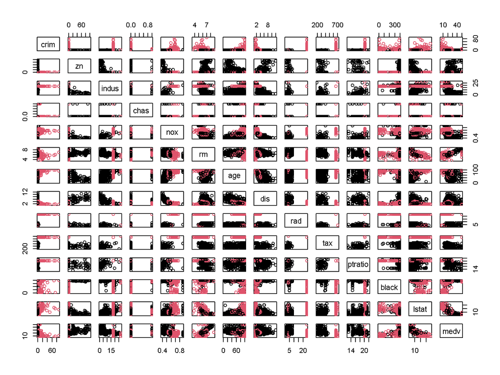

```r
km$cluster <- as.factor(km$cluster)

# plot the Boston dataset with clusters
pairs(Boston, col = km$cluster)
```

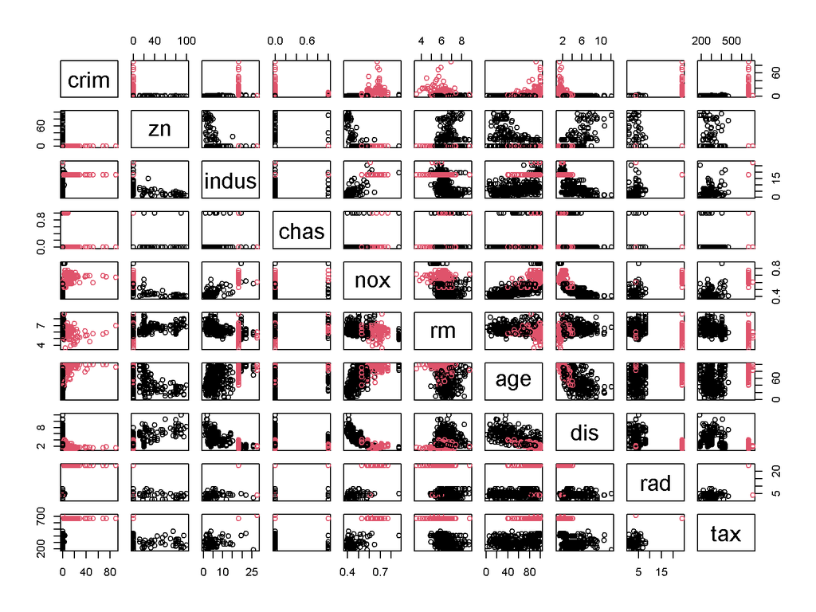

```r
#taking a closer look at the clusters in the data
pairs(Boston[1:10], col = km$cluster)
```

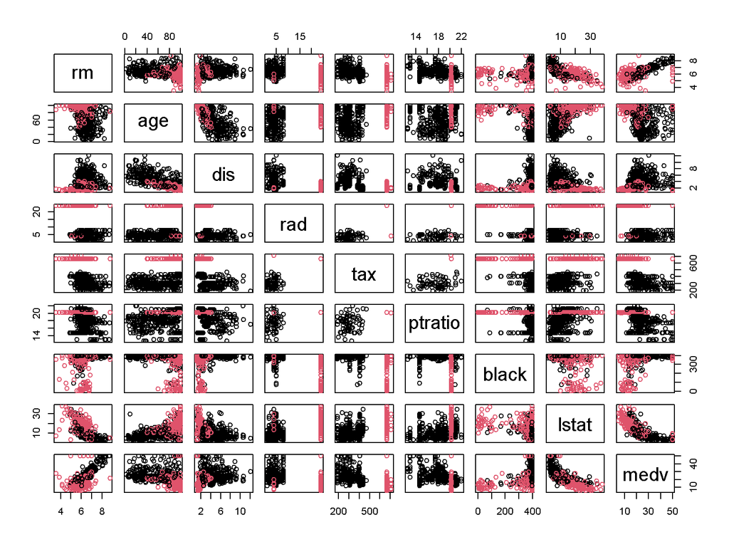

```r
pairs(Boston[6:14], col = km$cluster)
```

## Dimensionality reduction techniques

This week I learned new techniques to reduce the dimensionality of a dataset. With the data already saved into R, I performed and interpreted principal component analysis and Multiple Correspondence Analysis. All the R codes, interpretations and explanations of the analysis exercises are found below.

data source: http://hdr.undp.org/en/content/human-development-index-hdi

```r
date()
```

```
## [1] "Mon Dec 13 11:24:21 2021"
```

### Step 1:

The data used in this exercise is a joined data set of Human Development Index and Gender Development Index that is available on the United Nations Development Programme’s website (link above). The human data set consists of 155 countries (observations) and 8 variables.

Description of the variables in the human data:

gni = Gross National Income (GNI) per capita lifex = Life expectancy at birth expedu = Expected years of schooling matmor = Maternal mortality ratio adlbr = Adolescent birth rate reppar = Percentage of female representatives in parliament ratio_2edu = the ratio of Female and Male populations with secondary education in each country (edu2F / edu2M) ratio_lab = the ratio of labour force participation of females and males in each country (labF / labM)

The dimensions of the data and summaries of the variables are shown below.

```r
setwd("~/Git/IODS-project")
human <- read.table("C:/Users/irisp/Documents/Git/IODS-project/data/human.csv")

# access the following packages
library(tidyr); library(dplyr); library(ggplot2); library(GGally); library(corrplot)

dim (human)
```

```
## [1] 155   8
```

```r
summary (human)
```

```
##    ratio_2edu       ratio_lab          lifex           expedu
##  Min.   :0.1717   Min.   :0.1857   Min.   :49.00   Min.   : 5.40
##  1st Qu.:0.7264   1st Qu.:0.5984   1st Qu.:66.30   1st Qu.:11.25
##  Median :0.9375   Median :0.7535   Median :74.20   Median :13.50
##  Mean   :0.8529   Mean   :0.7074   Mean   :71.65   Mean   :13.18
##  3rd Qu.:0.9968   3rd Qu.:0.8535   3rd Qu.:77.25   3rd Qu.:15.20
##  Max.   :1.4967   Max.   :1.0380   Max.   :83.50   Max.   :20.20
##       gni             matmor           adlbr            reppar
##  Min.   :   581   Min.   :   1.0   Min.   :  0.60   Min.   : 0.00
##  1st Qu.:  4198   1st Qu.:  11.5   1st Qu.: 12.65   1st Qu.:12.40
##  Median : 12040   Median :  49.0   Median : 33.60   Median :19.30
##  Mean   : 17628   Mean   : 149.1   Mean   : 47.16   Mean   :20.91
##  3rd Qu.: 24512   3rd Qu.: 190.0   3rd Qu.: 71.95   3rd Qu.:27.95
##  Max.   :123124   Max.   :1100.0   Max.   :204.80   Max.   :57.50
```

Below you can see two graphical overviews of the data. From the ggpairs visualization we can see that variables ratio_edu2 and expedu have a normal distribution, the distributions of the variables ratio_lab and lifex are skewed towards right (meaning there are more higher values than lower values) and the distributions of the rest of the variables is skewed towards left (meaning there are more lower than higher values).

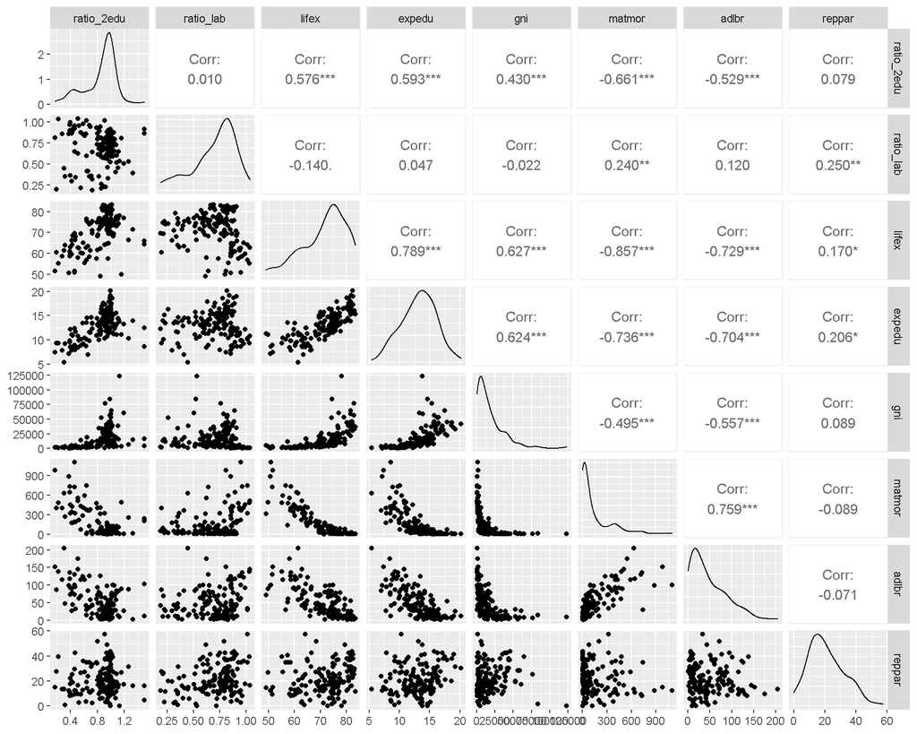

```r
# visualize the 'human' variables
ggpairs(human)
```

From the ggpairs plot and correlation plot (corrplot) we can comment on the relationships between the variables.

We can see positive and statistically significant correlations between the following variables:

- lifex and ratio_2edu, gni and reppar, meaning that the higher the life expectancy in a country is, the higher the ratio of female and male populations with secondary education, GNI and percentage of female representatives in parliament are.
- expedu and ratio_2edu, lifex, gni and reppar, meaning that the higher expected years of schooling is, the higher the ratio of female and male populations with secondary education is, life expectancy, GNI and percentage of female representatives in parliament are.
- gni and ratio_2edu, lifex and expedu, meaning that the higher the GNI is, the higher the ratio of female and male populations with secondary education is, life expectancy and expected years of schooling are.
- matmor and adlbr and ratio_lab, meaning that the higher the maternal mortality ratio is, the higher the adolescent birth rate and the ratio of labour force participation of females and males are.
- reppar and ratio_lab, lifex and expedu, meaning that the the higher the percentage of female representatives in parliament are, the higher the ratio of labour force participation of females and males, life expectancy and expected years of schooling are.

We can see negative and statistically significant correlations between the following variables:

- lifex and matmor and adlbr, meaning that the higher the life expectancy in a country is, the lower the maternal mortality ratio and adolescent birth rate are.
- expedu and matmor and adlbr, meaning that the higher the expected years of schooling in a country is, the lower the maternal mortality ratio and adolescent birth rate are.
- gni and matmor and adlbr, meaning that the higher the GNI of a country is, the lower the maternal mortality ratio and adolescent birth rate are.
- matmor and ratio_2edu, lifex, expedu and gni, meaning that the higher the maternal mortality ratio is, the lower the the ratio of female and male populations with secondary education, life expectancy, expected years of schooling and GNI are.
- adlbr and ratio_2edu, lifex, expedu and gni, meaning that the higher the adolescent birth rate is, the lower the the ratio of female and male populations with secondary education, life expectancy, expected years of schooling and GNI are.

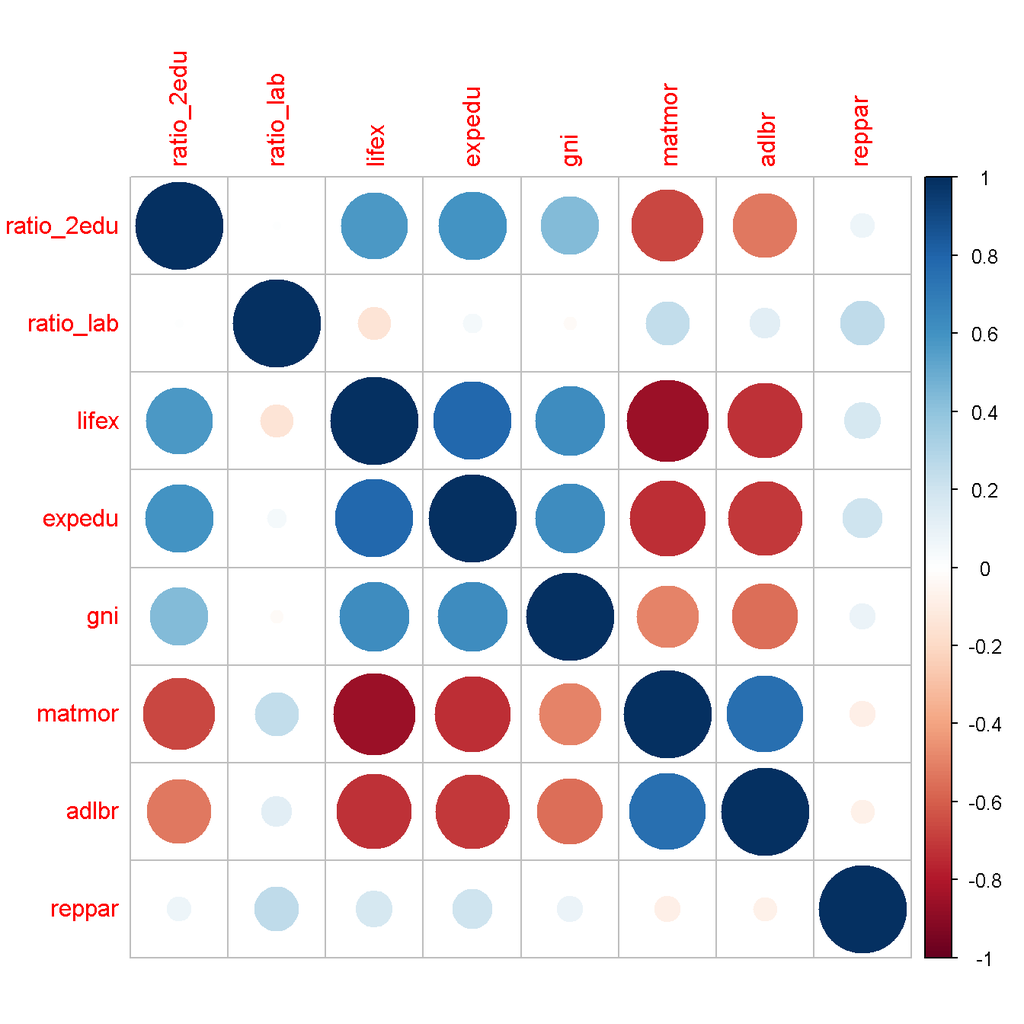

```r
# compute the correlation matrix and visualize it with corrplot
cor(human) %>% corrplot
```

### Step 2:

Next, Principal Component Analysis (PCA) is performed by the Singular Value Decomposition (SVD). The prcomp() function in R uses the SVD and is the preferred, more numerically accurate method. It decomposes a data matrix into a product of smaller matrices, which let’s us extract the underlying principal components. This makes it possible to approximate a lower dimensional representation of the data by choosing only a few principal components.

First, the PCA is performed with the not standardized human data. From the summary of the PCA1, we can see that the data is transformed to 8 different dimensions called principal components. Most variability in the data are captured by the first and second principal components (see standard deviations). The 1st principal component captures the maximum amount of variance from the features in the original data; the 2nd principal component captures the maximum amount of variability left and this is true for each of the following principal components. All the principal components are all uncorreleated and each of them is less important than the previous one, in terms of captured variance.

```r
# perform principal component analysis (with the SVD method)
pca1_human <- prcomp(human)

pca1 <- summary(pca1_human)

pca1
```

```
## Importance of components:
##                              PC1      PC2   PC3   PC4   PC5   PC6    PC7    PC8
## Standard deviation     1.854e+04 185.5219 25.19 11.45 3.766 1.566 0.1912 0.1591
## Proportion of Variance 9.999e-01   0.0001  0.00  0.00 0.000 0.000 0.0000 0.0000
## Cumulative Proportion  9.999e-01   1.0000  1.00  1.00 1.000 1.000 1.0000 1.0000
```

Below is a biplot of the PCA with unstandardized data displaying the observations by the first two principal components (PC1 coordinate in x-axis, PC2 coordinate in y-axis), along with arrows representing the original variables.

A biplot is a way of visualizing the connections between two representations of the same data. A biplot consists of a scatter plot in which the observations are placed on x and y coordinates defined by two principal components (PC’s) and arrows, which visualize the connections between the original variables and the PC’s. The following connections hold:

- The angle between the arrows can be interpret as the correlation between the variables.
- The angle between a variable and a PC axis can be interpret as the correlation between the two.
- The length of the arrows are proportional to the standard deviations of the variables

From the figure below, it is difficult to see the arrows and thus, interpret it properly. The first PC captures all the variation in the data and that is the reason why PC2 captures 0 % of the variability. GNI feature contributes to the first PC as its arrow is pointing towards the direction of the x-axis and even though, we cannot see the arrows of the other features, they probably contribute to the first PC as well because of the amount of the variance the first PC captures.

```r
# rounded percentages of variance captured by each PC
pca_pr <- round(100*pca1$importance[2,], digits = 1)

# print out the percentages of variance
pca_pr
```

```
## PC1 PC2 PC3 PC4 PC5 PC6 PC7 PC8
## 100   0   0   0   0   0   0   0
```

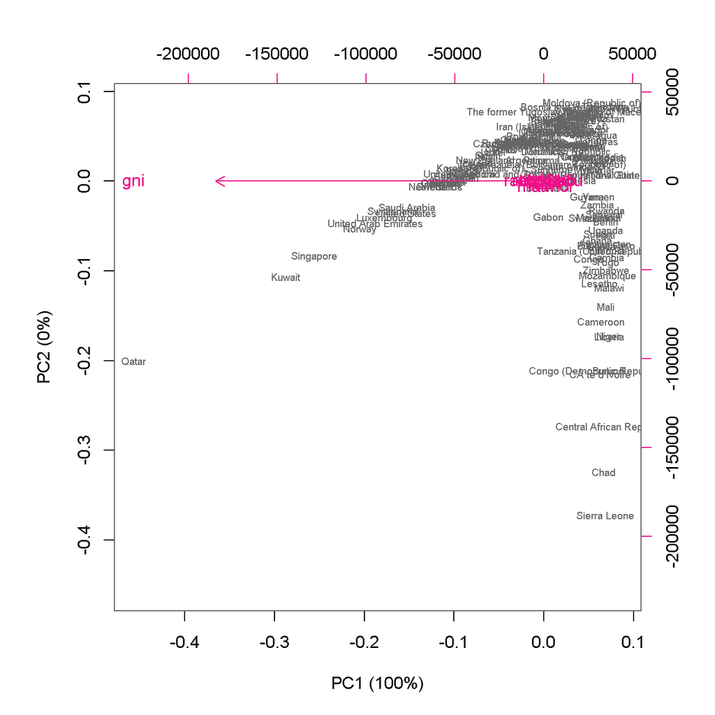

```r
# create object pc_lab to be used as axis labels
pc_lab <- paste0(names(pca_pr), " (", pca_pr, "%)")

# draw a biplot of the principal component representation and the original variables
biplot(pca1_human, cex = c(0.6, 1), col = c("grey40", "deeppink2"), xlab = pc_lab[1], ylab = pc_lab[2])
```

### Step 3:

Second, I standardize the variables in the human data and repeat the above principal component analysis. From the summary of the PCA2, we can see the first PC again captures most variability in the data and the second PC the second most. The results between PCA1 and PCA2 differ because of the standardization of the data. Standardization is needed to get more accurate results as PCA is sensitive to the relative scaling of the original features and assumes that features with larger variance are more important than features with smaller variance.

```r
# standardize the variables
human_std <- scale(human)

# perform principal component analysis (with the SVD method)
pca2_human <- prcomp(human_std)

pca2 <- summary(pca2_human)

pca2
```

```
## Importance of components:
##                           PC1    PC2     PC3     PC4     PC5     PC6     PC7
## Standard deviation     2.0708 1.1397 0.87505 0.77886 0.66196 0.53631 0.45900
## Proportion of Variance 0.5361 0.1624 0.09571 0.07583 0.05477 0.03595 0.02634
## Cumulative Proportion  0.5361 0.6984 0.79413 0.86996 0.92473 0.96069 0.98702
##                            PC8
## Standard deviation     0.32224
## Proportion of Variance 0.01298
## Cumulative Proportion  1.00000
```

From the figure below, we see that the first PC captures 53.6 % and second PC 16.2 % of the variation in the data. Expedu, lifex, ratio_2edu and gni features contribute to the first PC as well as matmor and adlbr, even though they point to the opposite direction than the other four featues. When features diverge and form a large angle (close to 180°), they are negatively correlated with each other which the correlations and correlation plot above also confirm: expedu, lifex, ratio_2edu and gni correlate strongly with each other and all of them correlate negatively with matmor and adlbr, that in turn, correlate quite highly positively with each other. We can see this from the vectors that each of the features have: when the vectors are close to each other and form a small angle, the variables they represent are positively correlated.

Reppar and ratio_lab features in turn contribute to the second PC as their arrows point to to the direction of the y-axis. Reppar and ratio_lab meet the other features at 90°, which means those variables they represent are not likely to be correlated. This is also supported by the descriptive statistics at the beginning of this exercise.

Compared to biplot of PCA1, the observations (countries) are more spread accross the scatter plot; in the PCA1 biplot the observations were concentrated on the top right corner of the plot. This difference is also due to the different scaling of the data. Also, in the PCA1, GNI feature is assumed to be more important than the other features because GNI has the largest variance of the original scale of the data. The features with smaller variance are all concentrated on one point in the PCA1 biplot but when the original scales are standardized all the features are assumed to have the same importance and none of them stand out in the PCA2 biplot.

```r
# rounded percentages of variance captured by each PC
pca_pr_std <- round(100*pca2$importance[2,], digits = 1)

# print out the percentages of variance
pca_pr_std
```

```
##  PC1  PC2  PC3  PC4  PC5  PC6  PC7  PC8
## 53.6 16.2  9.6  7.6  5.5  3.6  2.6  1.3
```

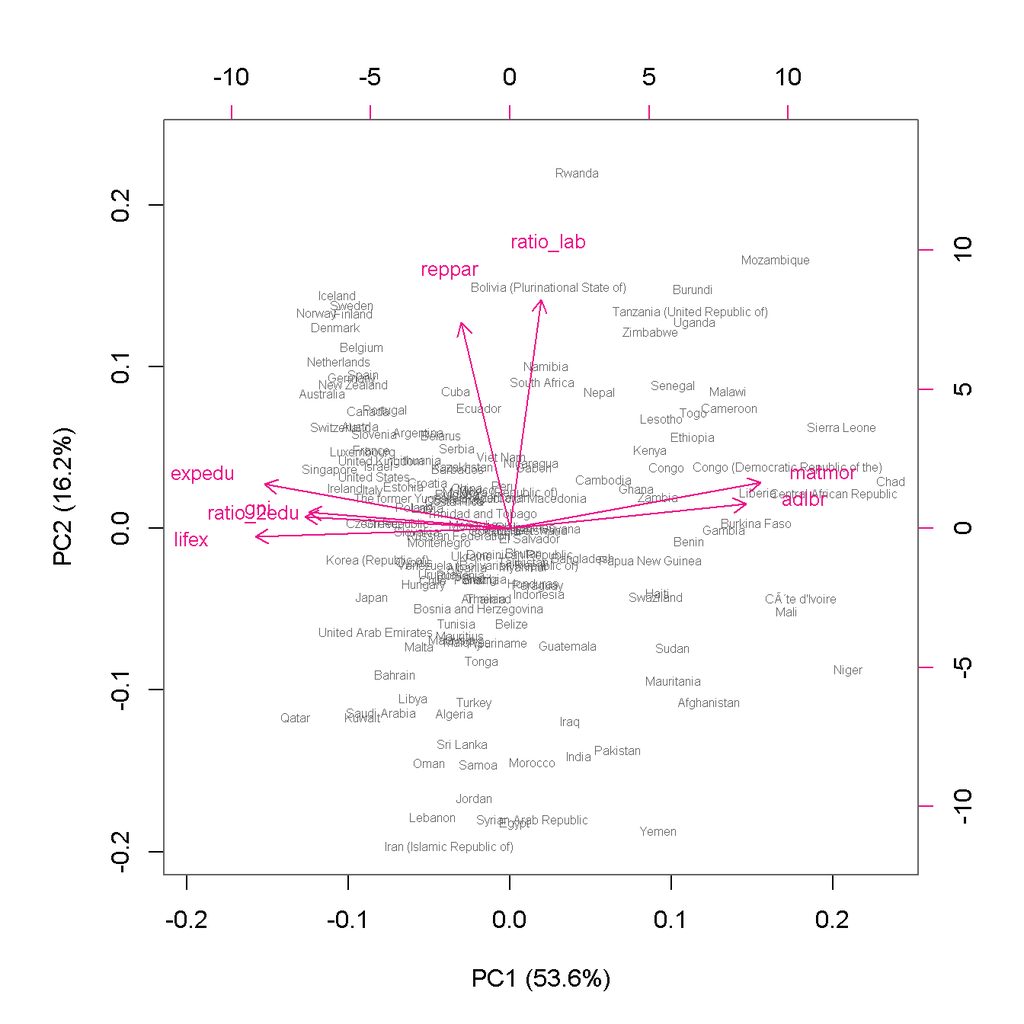

```r
# create object pc_lab to be used as axis labels
pc_lab_std <- paste0(names(pca_pr_std), " (", pca_pr_std, "%)")

# draw a biplot
biplot(pca2_human, cex = c(0.5, 0.8), col = c("grey40", "deeppink2"),
       xlab = pc_lab_std[1], ylab = pc_lab_std[2])
```

### Step 4:

I would interpret that the first two principal component dimensions based on the biplot drawn after PCA on the standardized human data represent following:

- The first principal component is influenced by these features: Gross National Income per capita, life expectancy at birth, expected years of schooling, the ratio of Female and Male populations with secondary education in each country, maternal mortality ratio and adolescent birth rate. I would think this PC represents the development of a society in terms of wealth, health and education.
- The second principal component is influenced by these two features: percentage of female representatives in parliament and the ratio of labour force participation of females and males in each country. I would think this PC represents gender inequality in labour market.

### Step 5:

Lastly, I perform the Multiple Correspondence Analysis on the tea data (loaded from the package Factominer). Before the analysis, I explored the structure and the dimensions of the data and visualized it after selecting six columns of the data to keep for the analysis.

```r
#install.packages("FactoMineR")
library(FactoMineR)

# load the data
data("tea")
str(tea)
```

```
## 'data.frame':    300 obs. of  36 variables:
##  $ breakfast       : Factor w/ 2 levels "breakfast","Not.breakfast": 1 1 2 2 1 2 1 2 1 1 ...
##  $ tea.time        : Factor w/ 2 levels "Not.tea time",..: 1 1 2 1 1 1 2 2 2 1 ...
##  $ evening         : Factor w/ 2 levels "evening","Not.evening": 2 2 1 2 1 2 2 1 2 1 ...
##  $ lunch           : Factor w/ 2 levels "lunch","Not.lunch": 2 2 2 2 2 2 2 2 2 2 ...
##  $ dinner          : Factor w/ 2 levels "dinner","Not.dinner": 2 2 1 1 2 1 2 2 2 2 ...
##  $ always          : Factor w/ 2 levels "always","Not.always": 2 2 2 2 1 2 2 2 2 2 ...
##  $ home            : Factor w/ 2 levels "home","Not.home": 1 1 1 1 1 1 1 1 1 1 ...
##  $ work            : Factor w/ 2 levels "Not.work","work": 1 1 2 1 1 1 1 1 1 1 ...
##  $ tearoom         : Factor w/ 2 levels "Not.tearoom",..: 1 1 1 1 1 1 1 1 1 2 ...
##  $ friends         : Factor w/ 2 levels "friends","Not.friends": 2 2 1 2 2 2 1 2 2 2 ...
##  $ resto           : Factor w/ 2 levels "Not.resto","resto": 1 1 2 1 1 1 1 1 1 1 ...
##  $ pub             : Factor w/ 2 levels "Not.pub","pub": 1 1 1 1 1 1 1 1 1 1 ...
##  $ Tea             : Factor w/ 3 levels "black","Earl Grey",..: 1 1 2 2 2 2 2 1 2 1 ...
##  $ How             : Factor w/ 4 levels "alone","lemon",..: 1 3 1 1 1 1 1 3 3 1 ...
```

[output cut: 22 more lines]

```r
dim(tea)
```

```
## [1] 300  36
```

```r
# column names to keep in the dataset
keep_columns <- c("Tea", "How", "how", "sugar", "where", "lunch")

# select the 'keep_columns' to create a new dataset
tea_time <- dplyr::select(tea, one_of(keep_columns))

# look at the summaries and structure of the data
summary(tea_time)
```

```
##         Tea         How                      how           sugar
##  black    : 74   alone:195   tea bag           :170   No.sugar:155
##  Earl Grey:193   lemon: 33   tea bag+unpackaged: 94   sugar   :145
##  green    : 33   milk : 63   unpackaged        : 36
##                  other:  9
##                   where           lunch
##  chain store         :192   lunch    : 44
##  chain store+tea shop: 78   Not.lunch:256
##  tea shop            : 30
##
```

```r
str(tea_time)
```

```
## 'data.frame':    300 obs. of  6 variables:
##  $ Tea  : Factor w/ 3 levels "black","Earl Grey",..: 1 1 2 2 2 2 2 1 2 1 ...
##  $ How  : Factor w/ 4 levels "alone","lemon",..: 1 3 1 1 1 1 1 3 3 1 ...
##  $ how  : Factor w/ 3 levels "tea bag","tea bag+unpackaged",..: 1 1 1 1 1 1 1 1 2 2 ...
##  $ sugar: Factor w/ 2 levels "No.sugar","sugar": 2 1 1 2 1 1 1 1 1 1 ...
##  $ where: Factor w/ 3 levels "chain store",..: 1 1 1 1 1 1 1 1 2 2 ...
##  $ lunch: Factor w/ 2 levels "lunch","Not.lunch": 2 2 2 2 2 2 2 2 2 2 ...
```

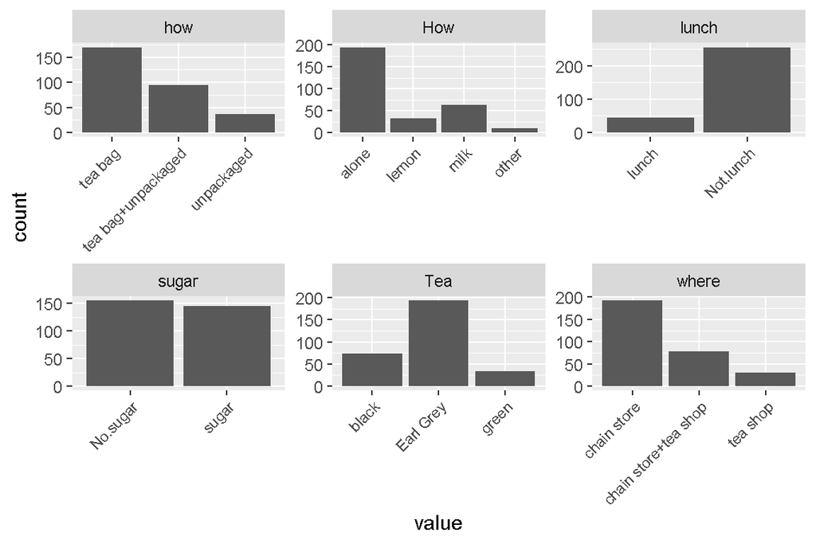

```r
# visualize the dataset
gather(tea_time) %>% ggplot(aes(value)) + facet_wrap("key", scales = "free") + geom_bar() + theme(axis.text.x = element_text(angle = 45, hjust = 1, size = 8))
```

Next, Multiple Correspondence Analysis (MCA) is performed on the tea data. MCA is a method to analyze qualitative adn/or categorical data and it is an extension of Correspondence analysis (CA). MCA can be used to detect patterns or structure in the data as well as in dimension reduction, just like PCA.

MCA summary contains the following information of the MCA dimensions:

- Eigenvalues, which are the variances and the percentage of variances retained by each dimension and as in the PCA, the first dimension captures most variability in the data and the following less and less.
- Individuals, which are the individuals coordinates, the individuals contribution (%) on the dimension and the cos2 (the squared correlations) on the dimensions.
- Categories, which are the coordinates of the variable categories, the contribution (%), the cos2 (the squared correlations) and v.test value. The v.test follows normal distribution: if the value is below/above ± 1.96, the coordinate is significantly different from zero. For the first dimension, only two categories are not significantly different from zero: sugar and alone, others are significant. For the second dimension, only category black is not significant and for the third dimension, categories green, milk, tea bag, tea bag+unpackaged and unpackaged are not significant.
- Categorical variables which represent the squared correlation between each variable and the dimensions. If the value is close to one, it indicates a strong link. The original categorical variables how and where influence strongly on the first dimension but also on the second dimension; and tea, How and sugar on the third dimension. Variable lunch does not share a strong link with none of the first three dimensions.

```r
# multiple correspondence analysis
mca <- MCA(tea_time, graph = FALSE)

# summary of the model
summary(mca)
```

```
##
## Call:
## MCA(X = tea_time, graph = FALSE)
##
##
## Eigenvalues
##                        Dim.1   Dim.2   Dim.3   Dim.4   Dim.5   Dim.6   Dim.7
## Variance               0.279   0.261   0.219   0.189   0.177   0.156   0.144
## % of var.             15.238  14.232  11.964  10.333   9.667   8.519   7.841
## Cumulative % of var.  15.238  29.471  41.435  51.768  61.434  69.953  77.794
##                        Dim.8   Dim.9  Dim.10  Dim.11
## Variance               0.141   0.117   0.087   0.062
## % of var.              7.705   6.392   4.724   3.385
## Cumulative % of var.  85.500  91.891  96.615 100.000
##
## Individuals (the 10 first)
##                       Dim.1    ctr   cos2    Dim.2    ctr   cos2    Dim.3
## 1                  | -0.298  0.106  0.086 | -0.328  0.137  0.105 | -0.327
## 2                  | -0.237  0.067  0.036 | -0.136  0.024  0.012 | -0.695
## 3                  | -0.369  0.162  0.231 | -0.300  0.115  0.153 | -0.202
## 4                  | -0.530  0.335  0.460 | -0.318  0.129  0.166 |  0.211
## 5                  | -0.369  0.162  0.231 | -0.300  0.115  0.153 | -0.202
## 6                  | -0.369  0.162  0.231 | -0.300  0.115  0.153 | -0.202
## 7                  | -0.369  0.162  0.231 | -0.300  0.115  0.153 | -0.202
## 8                  | -0.237  0.067  0.036 | -0.136  0.024  0.012 | -0.695
## 9                  |  0.143  0.024  0.012 |  0.871  0.969  0.435 | -0.067
## 10                 |  0.476  0.271  0.140 |  0.687  0.604  0.291 | -0.650
##                       ctr   cos2
## 1                   0.163  0.104 |
## 2                   0.735  0.314 |
## 3                   0.062  0.069 |
## 4                   0.068  0.073 |
## 5                   0.062  0.069 |
## 6                   0.062  0.069 |
## 7                   0.062  0.069 |
## 8                   0.735  0.314 |
## 9                   0.007  0.003 |
## 10                  0.643  0.261 |
##
## Categories (the 10 first)
```

[output cut: 16 more lines]

```
## lemon                3.226 |   1.329  14.771   0.218   8.081 |
## milk                 2.422 |   0.013   0.003   0.000   0.116 |
## other                5.534 |  -2.524  14.526   0.197  -7.676 |
## tea bag             -6.941 |  -0.065   0.183   0.006  -1.287 |
## tea bag+unpackaged  11.956 |   0.019   0.009   0.000   0.226 |
## unpackaged          -6.482 |   0.257   0.602   0.009   1.640 |
##
## Categorical variables (eta2)
##                      Dim.1 Dim.2 Dim.3
## Tea                | 0.126 0.108 0.410 |
## How                | 0.076 0.190 0.394 |
## how                | 0.708 0.522 0.010 |
## sugar              | 0.065 0.001 0.336 |
## where              | 0.702 0.681 0.055 |
## lunch              | 0.000 0.064 0.111 |
```

I have drawn below a variable biplot of the analysis where are variables drawn on the first two dimensions. The MCA biplot visualizes variable patterns in the data and the distances between variable categories gives a measure of their similarity. For example categories milk, Earl grey and sugar are more similar to each other than black and no sugar which in turn are similar. Also not lunch and alone are similar to each other as their distance from each other is short. Unpackaged and tea shop are different from all the other categories since they are located further away from the others. We can also see that first dimension captures 15.24 % of the variation and second dimension 14.23 % of the variation in the data.

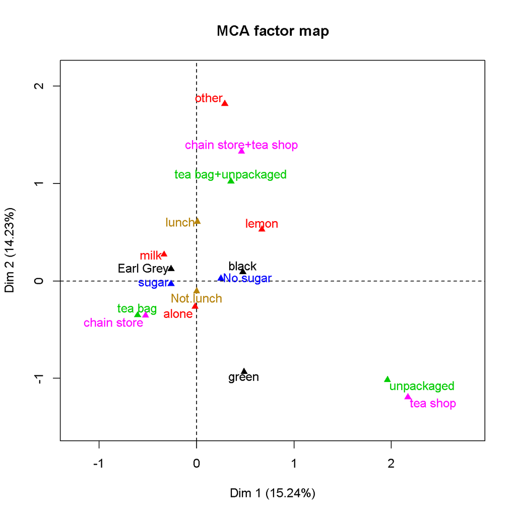

```r
# visualize MCA
plot(mca, invisible=c("ind"), habillage = "quali", graph.type = "classic")
```

## Analysis of longitudinal data

This week I learned new techniques to work with and analyse longitudinal data. With the data sets RATS and BPRSL already saved into R, I performed and interpreted t-tests, Analysis of Variance, regression and multilevel analysis. All the R codes, interpretations and explanations of the analysis exercises are found below.

data sources: https://raw.githubusercontent.com/KimmoVehkalahti/MABS/master/Examples/data/BPRS.txt

https://raw.githubusercontent.com/KimmoVehkalahti/MABS/master/Examples/data/rats.txt

```r
date()
```

```
## [1] "Mon Dec 13 11:24:31 2021"
```

```r
setwd("~/Git/IODS-project")
RATSL <- read.table("C:/Users/irisp/Documents/Git/IODS-project/data/RATSL.csv")
BPRSL <- read.table("C:/Users/irisp/Documents/Git/IODS-project/data/BPRSL.csv")
BPRS <- read.table("https://raw.githubusercontent.com/KimmoVehkalahti/MABS/master/Examples/data/BPRS.txt", sep  =" ", header = T)
RATS <- read.table("https://raw.githubusercontent.com/KimmoVehkalahti/MABS/master/Examples/data/rats.txt", header = TRUE, sep = '\t')


# access the following packages
library(tidyr); library(dplyr); library(ggplot2)

#Convert the categorical variables of both data sets to factors
BPRSL$treatment <- factor(BPRSL$treatment)
BPRSL$subject <- factor(BPRSL$subject)

RATSL$ID <- factor(RATSL$ID)
RATSL$Group <- factor(RATSL$Group)
```

### Step 1: Implementing the analyses of Chapter 8 of MABS using the RATS data

For the t-tests and Analysis of Variance, I use data from a nutrition study conducted in three groups of rats. The groups were put on different diets, and each animal’s body weight (grams) was recorded repeatedly (approximately) weekly, except in week seven when two recordings were taken) over a 9-week period. We are interested in whether the growth profiles of the three groups differ.

Graphical displays of data are almost always useful for exposing patterns in the data, particularly when these are unexpected; this might be of great help in suggesting which class of models might be most sensibly applied in the later more formal analysis.

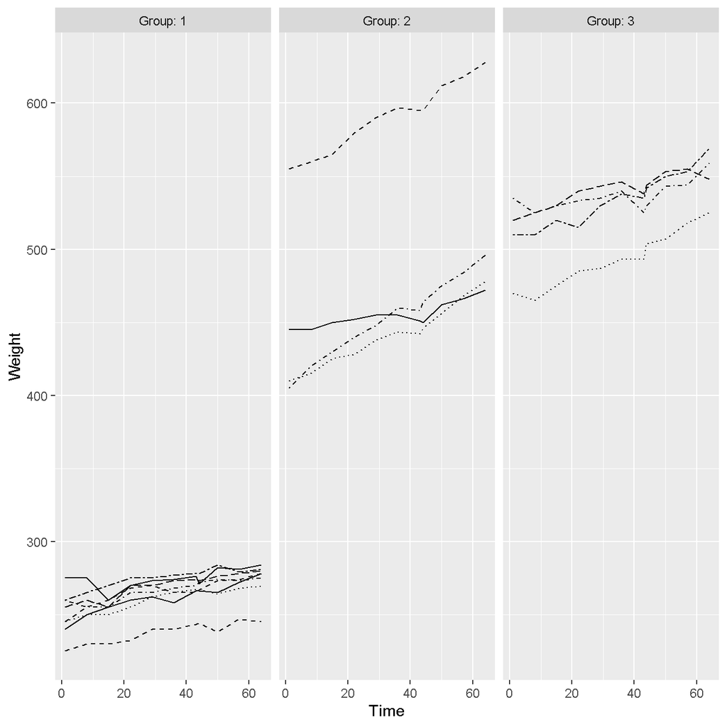

```r
# Draw the plot
ggplot(RATSL, aes(x = Time, y = Weight, linetype = ID)) +
  geom_line() +
  scale_linetype_manual(values = rep(1:10, times=4)) +
  facet_grid(. ~ Group, labeller = label_both) +
  theme(legend.position = "none") +
  scale_y_continuous(limits = c(min(RATSL$Weight), max(RATSL$Weight)))
```

An important effect we want to take notice is how the rats who have higher weight in grams at the beginning tend to have higher values as the study goes on. This phenomenon is generally referred to as tracking which can be seen more clearly in a plot of the standardized values of each observation (below).

With large numbers of observations, graphical displays of individual response profiles are of little use and investigators then commonly produce graphs showing average (mean) profiles for each treatment group along with some indication of the variation of the observations at each time point, in this case the standard error of mean.

```r
# Standardise the variable bprs
RATSL <- RATSL %>%
  group_by(Time) %>%
  mutate(stdrats = (Weight - mean(Weight))/sd(Weight) ) %>%
  ungroup()

# Glimpse the data
glimpse(RATSL)
```

```
## Rows: 176
## Columns: 6
## $ ID      <fct> 1, 2, 3, 4, 5, 6, 7, 8, 9, 10, 11, 12, 13, 14, 15, 16, 1, 2, 3~
## $ Group   <fct> 1, 1, 1, 1, 1, 1, 1, 1, 2, 2, 2, 2, 3, 3, 3, 3, 1, 1, 1, 1, 1,~
## $ WD      <chr> "WD1", "WD1", "WD1", "WD1", "WD1", "WD1", "WD1", "WD1", "WD1",~
## $ Weight  <int> 240, 225, 245, 260, 255, 260, 275, 245, 410, 405, 445, 555, 47~
## $ Time    <int> 1, 1, 1, 1, 1, 1, 1, 1, 1, 1, 1, 1, 1, 1, 1, 1, 8, 8, 8, 8, 8,~
## $ stdrats <dbl> -1.0011429, -1.1203857, -0.9613953, -0.8421525, -0.8819001, -0~
```

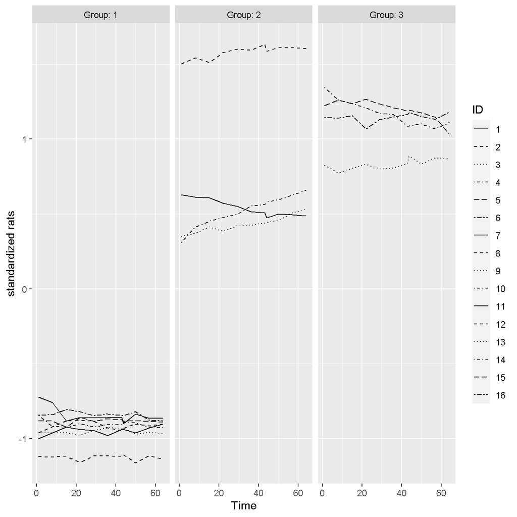

```r
# Plot again with the standardised bprs
ggplot(RATSL, aes(x = Time, y = stdrats, linetype = ID)) +
  geom_line() +
  scale_linetype_manual(values = rep(1:10, times=4)) +
  facet_grid(. ~ Group, labeller = label_both) +
  scale_y_continuous(name = "standardized rats")
```

```r
# Number of IDs (per group):
table (RATSL$Group, RATSL$ID)
```

```
##
##      1  2  3  4  5  6  7  8  9 10 11 12 13 14 15 16
##   1 11 11 11 11 11 11 11 11  0  0  0  0  0  0  0  0
##   2  0  0  0  0  0  0  0  0 11 11 11 11  0  0  0  0
##   3  0  0  0  0  0  0  0  0  0  0  0  0 11 11 11 11
```

```r
n <- 16

# Summary data with mean and standard error of bprs by treatment and week
RATSS <- RATSL %>%
  group_by(Group, Time) %>%
  summarise( mean = mean(Weight), se = sd(Weight)/sqrt(n) ) %>%
  ungroup()

# Glimpse the data
glimpse(RATSS)
```

```
## Rows: 33
## Columns: 4
## $ Group <fct> 1, 1, 1, 1, 1, 1, 1, 1, 1, 1, 1, 2, 2, 2, 2, 2, 2, 2, 2, 2, 2, 2~
## $ Time  <int> 1, 8, 15, 22, 29, 36, 43, 44, 50, 57, 64, 1, 8, 15, 22, 29, 36, ~
## $ mean  <dbl> 250.625, 255.000, 254.375, 261.875, 264.625, 265.000, 267.375, 2~
## $ se    <dbl> 3.805394, 3.273268, 2.868977, 3.400204, 2.764370, 2.945942, 2.73~
```

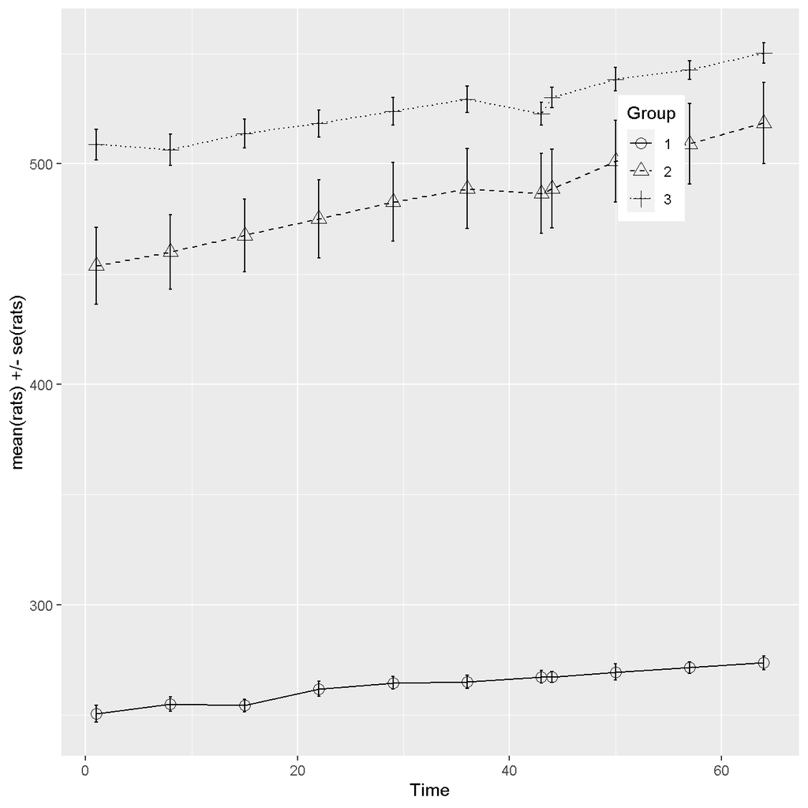

```r
# Plot the mean profiles
ggplot(RATSS, aes(x = Time, y = mean, linetype = Group, shape = Group)) +
  geom_line() +
  scale_linetype_manual(values = c(1,2,3)) +
  geom_point(size=3) +
  scale_shape_manual(values = c(1,2,3)) +
  geom_errorbar(aes(ymin = mean - se, ymax = mean + se, linetype="1"), width=0.3) +
  theme(legend.position = c(0.8,0.8)) +
  scale_y_continuous(name = "mean(rats) +/- se(rats)")
```

```r
# Create a summary data by group and ID with mean as the summary variable
RATSL64S <- RATSL %>%
  filter(Time > 0) %>%
  group_by(Group, ID) %>%
  summarise( mean=mean(Weight) ) %>%
  ungroup()
# Glimpse the data
glimpse(RATSL64S)
```

```
## Rows: 16
## Columns: 3
## $ Group <fct> 1, 1, 1, 1, 1, 1, 1, 1, 2, 2, 2, 2, 3, 3, 3, 3
## $ ID    <fct> 1, 2, 3, 4, 5, 6, 7, 8, 9, 10, 11, 12, 13, 14, 15, 16
## $ mean  <dbl> 261.0909, 237.6364, 260.1818, 266.5455, 269.4545, 274.7273, 274.~
```

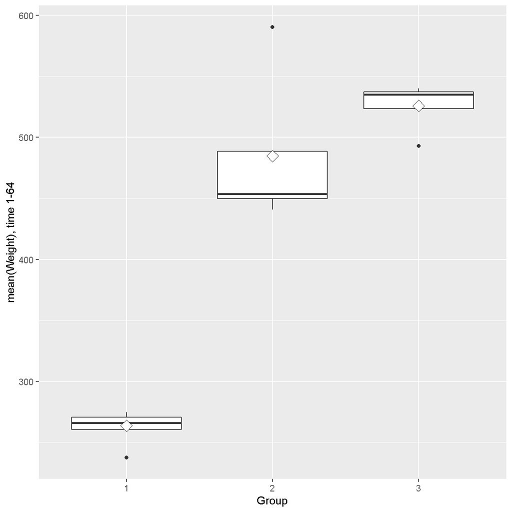

```r
# Draw a boxplot of the mean versus treatment
ggplot(RATSL64S, aes(x = Group, y = mean)) +
  geom_boxplot() +
  stat_summary(fun.y = "mean", geom = "point", shape=23, size=4, fill = "white") +
  scale_y_continuous(name = "mean(Weight), time 1-64")
```

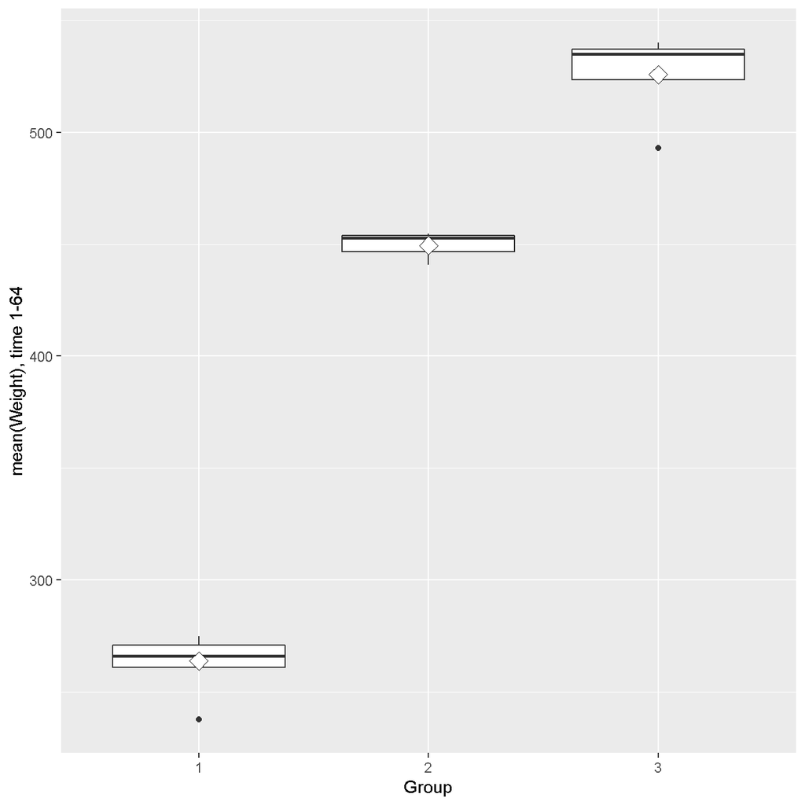

```r
# Create a new data by filtering the outlier and adjust the ggplot code the draw the plot again with the new data
RATSL64S1 <- RATSL64S %>%
  filter(mean < 560)

ggplot(RATSL64S1, aes(x = Group, y = mean)) +
  geom_boxplot() +
  stat_summary(fun.y = "mean", geom = "point", shape=23, size=4, fill = "white") +
  scale_y_continuous(name = "mean(Weight), time 1-64")
```

Although the informal graphical material presented up to now has all indicated differences in the three groups, we can still perform a formal test for a difference. Consequently I apply a t-test to assess any difference between the groups, and also calculate a confidence interval for this difference. I use the data without the outlier created in the previous exercise. The t-test confirms the evidence for group differences. Also the 95% confidence intervals between groups 1 and 2, and 1 and 3 are quite narrow and do not include zero. The the 95% confidence intervals between groups 2 and 3 are wider but they also do not include zero so we can conclude the group differences are statistically relevant.

```r
# Perform t-test on groups 1 & 2
t.test(mean[1:11] ~ Group[1:11], data = RATSL64S1, var.equal = TRUE)
```

```
##
##  Two Sample t-test
##
## data:  mean[1:11] by Group[1:11]
## t = -24.838, df = 9, p-value = 1.334e-09
## alternative hypothesis: true difference in means between group 1 and group 2 is not equal to 0
## 95 percent confidence interval:
##  -202.6549 -168.8224
## sample estimates:
## mean in group 1 mean in group 2
##        263.7159        449.4545
```

```r
# Perform t-test on groups 1 & 3
t.test(mean[c(1:8,12:15)] ~ Group[c(1:8,12:15)], data = RATSL64S1, var.equal = TRUE)
```

```
##
##  Two Sample t-test
##
## data:  mean[c(1:8, 12:15)] by Group[c(1:8, 12:15)]
## t = -27.361, df = 10, p-value = 9.848e-11
## alternative hypothesis: true difference in means between group 1 and group 3 is not equal to 0
## 95 percent confidence interval:
##  -283.4218 -240.7373
## sample estimates:
## mean in group 1 mean in group 3
##        263.7159        525.7955
```

```r
# Perform t-test on groups 2 & 3
t.test(mean[9:15] ~ Group[9:15], data = RATSL64S1, var.equal = TRUE)
```

```
##
##  Two Sample t-test
##
## data:  mean[9:15] by Group[9:15]
## t = -5.6287, df = 5, p-value = 0.002452
## alternative hypothesis: true difference in means between group 2 and group 3 is not equal to 0
## 95 percent confidence interval:
##  -111.20490  -41.47691
## sample estimates:
## mean in group 2 mean in group 3
##        449.4545        525.7955
```

Baseline measurements of the outcome variable in a longitudinal study are often correlated with the chosen summary measure and using such measures in the analysis can often lead to substantial gains in precision when used appropriately as a covariate in an analysis of covariance. We can illustrate the analysis on the data using the RATS value corresponding to time zero taken prior to the start of treatment as the baseline covariate. We see that the baseline RATS is strongly related to the RATS values taken after observation period has begun, and there is still little evidence of a group difference even after conditioning on the baseline value. Baseline is significant with p<0.000 and Group with p<0.1.

```r
# Add the baseline from the original data as a new variable to the summary data
RATSL64S2 <- RATSL64S %>%
  mutate(baseline = RATS$WD1)

# Fit the linear model with the mean as the response
fit <- lm(mean ~ baseline + Group, data = RATSL64S2)

# Compute the analysis of variance table for the fitted model with anova()
anova(fit)
```

```
## Analysis of Variance Table
##
## Response: mean
##           Df Sum Sq Mean Sq   F value    Pr(>F)
## baseline   1 252125  252125 2237.0655 5.217e-15 ***
## Group      2    726     363    3.2219   0.07586 .
## Residuals 12   1352     113
## ---
## Signif. codes:  0 '***' 0.001 '**' 0.01 '*' 0.05 '.' 0.1 ' ' 1
```

### Step 2: Implementing the analyses of Chapter 9 of MABS using the BPRS data

Longitudinal data, where a response variable is measured on each subject on several different occasions poses problems for their analysis because the repeated measurements on each subject are very likely to be correlated rather than independent.

To investigate the use of linear mixed effects models in practice, I use the BPRS data, in which 40 male subjects were randomly assigned to one oftwo treatment groups and each subject was rated on the brief psychiatric rating scale (BPRS) measured before treatment began (week 0) and then at weekly intervals for eight weeks. The BPRS assesses the level of 18 symptom constructs such as hostility, suspiciousness, hallucinations and grandiosity; each of these is rated from one (not present) to seven (extremely severe). The scale is used to evaluate patients suspected of having schizophrenia.

To begin, we shall ignore the repeated-measures structure of the data and assume that all the observations are independent of one another. Now if we simply ignore that the sets of bprs values come from the same male, we have a data set consisting of 360 bprs values, weeks, and group memberships that can be analyzed using multiple linear regression. To begin, I will plot the data, identifying the observations in each group but ignoring the longitudinal nature of the data.

The bprs values in treatment group 2 seem to be more varied than in group in 1 and there are more higher bprs values in treatment group 2 than group 1. It seems that in general, the bprs values derease over the 8-week period in both groups, but there are a few individuals whose bprs values increase during that period.

```r
# Check the dimensions of the data
dim(BPRSL)
```

```
## [1] 360   5
```

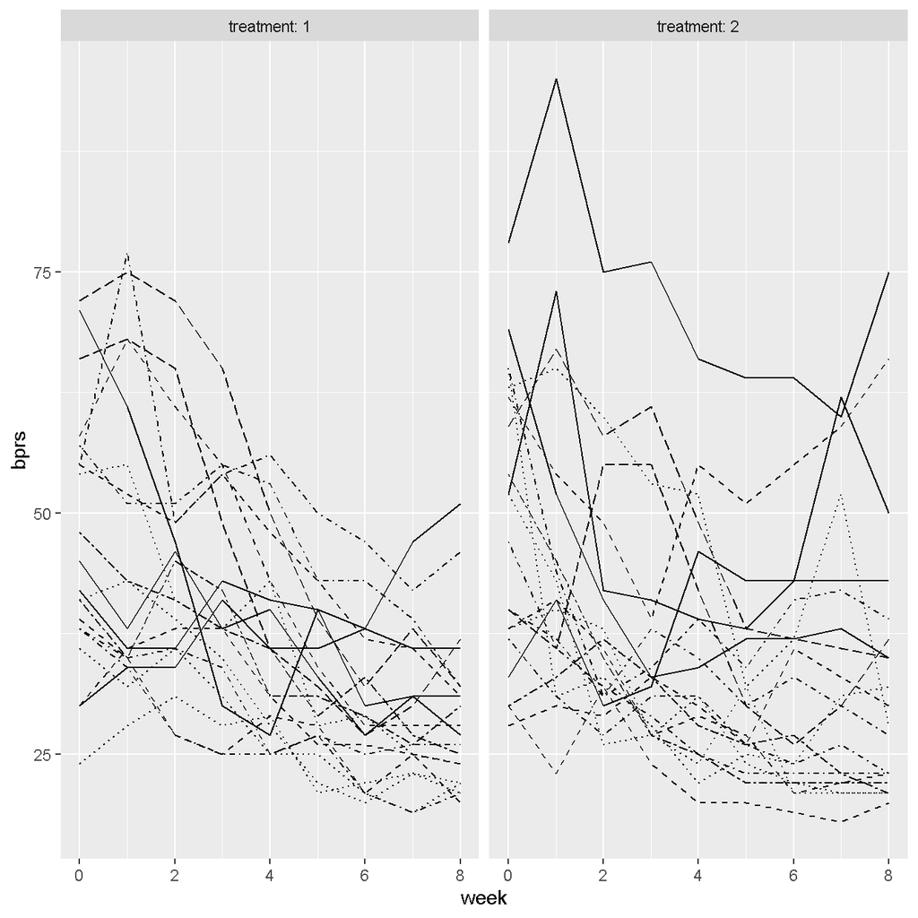

```r
# Plot the BPRSL data
ggplot(BPRSL, aes(x = week, y = bprs, linetype = subject)) +
  geom_line() +
  scale_linetype_manual(values = rep(1:10, times=4)) +
  facet_grid(. ~ treatment, labeller = label_both) +
  theme(legend.position = "none") +
  scale_y_continuous(limits = c(min(BPRSL$bprs), max(BPRSL$bprs)))
```

Observe 1) How treatment group 2 differ from group 1 conditional on weeks and 2) The significance of the regression on week. The linear regression shows that there is a significant relationship between bprs values and the treatment week (p<0.000) but there is no evidence that the two treatment groups have a significant effect on the bprs values: there is no evidence of statistical significance.

```r
# create a regression model RATS_reg
BPRSL_reg <- lm(bprs ~ week + treatment, data = BPRSL)

# print out a summary of the model
summary(BPRSL_reg)
```

```
##
## Call:
## lm(formula = bprs ~ week + treatment, data = BPRSL)
##
## Residuals:
##     Min      1Q  Median      3Q     Max
## -22.454  -8.965  -3.196   7.002  50.244
##
## Coefficients:
##             Estimate Std. Error t value Pr(>|t|)
## (Intercept)  46.4539     1.3670  33.982   <2e-16 ***
## week         -2.2704     0.2524  -8.995   <2e-16 ***
## treatment2    0.5722     1.3034   0.439    0.661
## ---
## Signif. codes:  0 '***' 0.001 '**' 0.01 '*' 0.05 '.' 0.1 ' ' 1
##
## Residual standard error: 12.37 on 357 degrees of freedom
## Multiple R-squared:  0.1851, Adjusted R-squared:  0.1806
## F-statistic: 40.55 on 2 and 357 DF,  p-value: < 2.2e-16
```

The previous model assumes independence of the repeated measures of bprs values, and this assumption is highly unlikely. So, now we will move on to consider both some more appropriate graphics and appropriate models.

To begin the more formal analysis of the bprs values data, I will first fit a random intercept model for the same two explanatory variables: week and treatment. Fitting a random intercept model allows the linear regression fit for each man to differ in intercept from other men.

```r
# access library lme4
library(lme4)
# Create a random intercept model
BPRSL_ref <- lmer(bprs ~ week + treatment + (1 | subject), data = BPRSL, REML = FALSE)

# Print the summary of the model
summary(BPRSL_ref)
```

```
## Linear mixed model fit by maximum likelihood  ['lmerMod']
## Formula: bprs ~ week + treatment + (1 | subject)
##    Data: BPRSL
##
##      AIC      BIC   logLik deviance df.resid
##   2748.7   2768.1  -1369.4   2738.7      355
##
## Scaled residuals:
##     Min      1Q  Median      3Q     Max
## -3.0481 -0.6749 -0.1361  0.4813  3.4855
##
## Random effects:
##  Groups   Name        Variance Std.Dev.
##  subject  (Intercept)  47.41    6.885
##  Residual             104.21   10.208
## Number of obs: 360, groups:  subject, 20
##
## Fixed effects:
##             Estimate Std. Error t value
## (Intercept)  46.4539     1.9090  24.334
## week         -2.2704     0.2084 -10.896
## treatment2    0.5722     1.0761   0.532
##
## Correlation of Fixed Effects:
##            (Intr) week
## week       -0.437
## treatment2 -0.282  0.000
```

Now we can move on to fit a random intercept and random slope model to the BPRS data. Fitting a random intercept and random slope model allows the linear regression fits for each individual to differ in intercept but also in slope. This way it is possible to account for the individual differences in the men’s bprs profiles, but also the effect of time.

```r
# create a random intercept and random slope model
BPRSL_ref1 <- lmer(bprs ~ week + treatment + (week | subject), data = BPRSL, REML = FALSE)

# print a summary of the model
summary(BPRSL_ref1)
```

```
## Linear mixed model fit by maximum likelihood  ['lmerMod']
## Formula: bprs ~ week + treatment + (week | subject)
##    Data: BPRSL
##
##      AIC      BIC   logLik deviance df.resid
##   2745.4   2772.6  -1365.7   2731.4      353
##
## Scaled residuals:
##     Min      1Q  Median      3Q     Max
## -2.8919 -0.6194 -0.0691  0.5531  3.7976
##
## Random effects:
##  Groups   Name        Variance Std.Dev. Corr
##  subject  (Intercept) 64.8222  8.0512
##           week         0.9609  0.9802   -0.51
##  Residual             97.4305  9.8707
## Number of obs: 360, groups:  subject, 20
##
## Fixed effects:
##             Estimate Std. Error t value
## (Intercept)  46.4539     2.1052  22.066
## week         -2.2704     0.2977  -7.626
## treatment2    0.5722     1.0405   0.550
##
## Correlation of Fixed Effects:
##            (Intr) week
## week       -0.582
## treatment2 -0.247  0.000
```

```r
# perform an ANOVA test on the two models
anova(BPRSL_ref1, BPRSL_ref)
```

```
## Data: BPRSL
## Models:
## BPRSL_ref: bprs ~ week + treatment + (1 | subject)
## BPRSL_ref1: bprs ~ week + treatment + (week | subject)
##            npar    AIC    BIC  logLik deviance  Chisq Df Pr(>Chisq)
## BPRSL_ref     5 2748.7 2768.1 -1369.4   2738.7
## BPRSL_ref1    7 2745.4 2772.6 -1365.7   2731.4 7.2721  2    0.02636 *
## ---
## Signif. codes:  0 '***' 0.001 '**' 0.01 '*' 0.05 '.' 0.1 ' ' 1
```

Finally, we fit a random intercept and slope model that allows for a treatment group and week interaction.

Again pay attention to the likelihood ratio test chi-squared value and the according p-value. The lower the value the better the fit against the comparison model.

```r
# create a random intercept and random slope model
BPRSL_ref2 <- lmer(bprs ~ week * treatment + (week | subject), data = BPRSL, REML = FALSE)

# print a summary of the model
summary(BPRSL_ref2)
```

```
## Linear mixed model fit by maximum likelihood  ['lmerMod']
## Formula: bprs ~ week * treatment + (week | subject)
##    Data: BPRSL
##
##      AIC      BIC   logLik deviance df.resid
##   2744.3   2775.4  -1364.1   2728.3      352
##
## Scaled residuals:
##     Min      1Q  Median      3Q     Max
## -3.0512 -0.6271 -0.0768  0.5288  3.9260
##
## Random effects:
##  Groups   Name        Variance Std.Dev. Corr
##  subject  (Intercept) 64.9964  8.0620
##           week         0.9687  0.9842   -0.51
##  Residual             96.4707  9.8220
## Number of obs: 360, groups:  subject, 20
##
## Fixed effects:
##                 Estimate Std. Error t value
## (Intercept)      47.8856     2.2521  21.262
## week             -2.6283     0.3589  -7.323
## treatment2       -2.2911     1.9090  -1.200
## week:treatment2   0.7158     0.4010   1.785
##
## Correlation of Fixed Effects:
##             (Intr) week   trtmn2
## week        -0.650
## treatment2  -0.424  0.469
## wek:trtmnt2  0.356 -0.559 -0.840
```

```r
# perform an ANOVA test on the two models
anova(BPRSL_ref2, BPRSL_ref1)
```

```
## Data: BPRSL
## Models:
## BPRSL_ref1: bprs ~ week + treatment + (week | subject)
## BPRSL_ref2: bprs ~ week * treatment + (week | subject)
##            npar    AIC    BIC  logLik deviance  Chisq Df Pr(>Chisq)
## BPRSL_ref1    7 2745.4 2772.6 -1365.7   2731.4
## BPRSL_ref2    8 2744.3 2775.4 -1364.1   2728.3 3.1712  1    0.07495 .
## ---
## Signif. codes:  0 '***' 0.001 '**' 0.01 '*' 0.05 '.' 0.1 ' ' 1
```

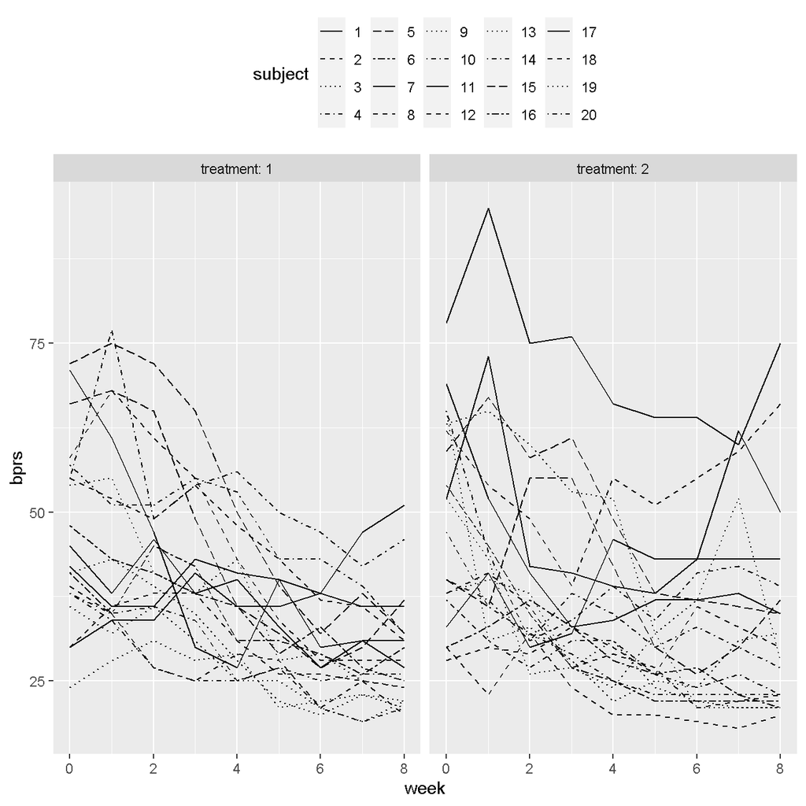

```r
# draw the plot of BPRSL
ggplot(BPRSL, aes(x = week, y = bprs, linetype = subject)) +
  geom_line(aes(linetype = subject)) +
  scale_linetype_manual(values = rep(1:10, times=4)) +
  facet_grid(. ~ treatment, labeller = label_both) +
  theme(legend.position = "top") +
  scale_y_continuous(limits = c(min(BPRSL$bprs), max(BPRSL$bprs)))
```

Here I create a vector of the fitted values of the model and draw the plot of fitted values of BPRSL.

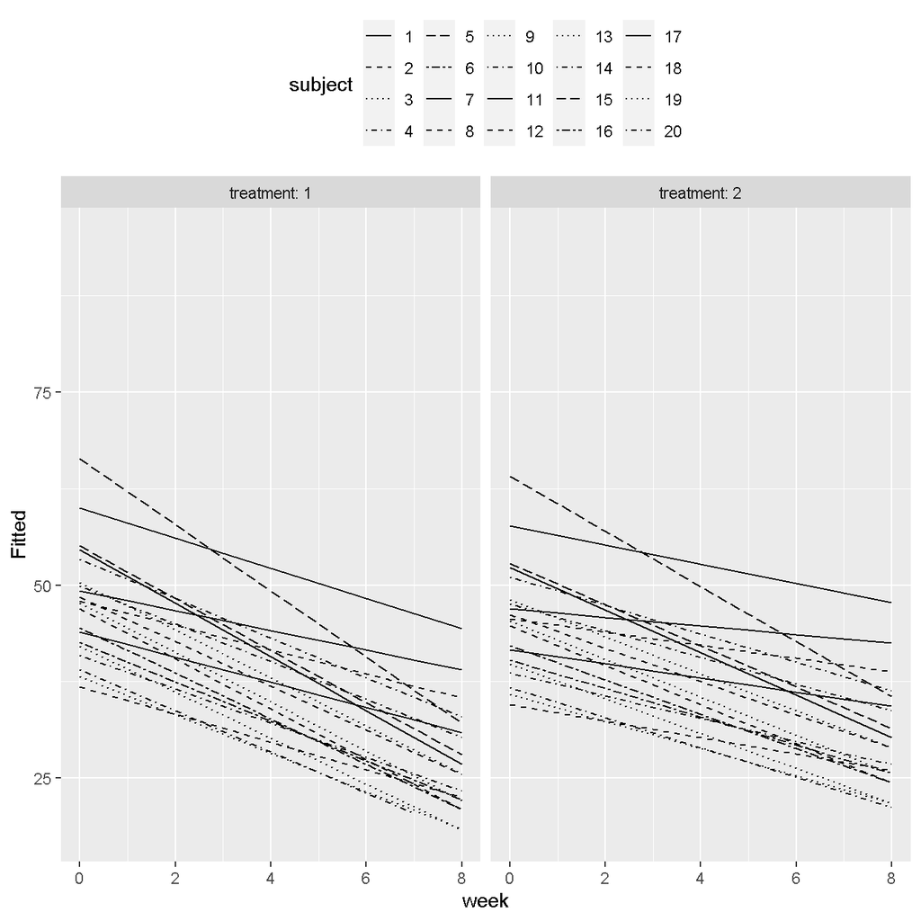

```r
# Create a vector of the fitted values
Fitted <- fitted(BPRSL_ref2)

# Create a new column fitted to RATSL
BPRSL <- BPRSL %>%
  mutate(Fitted)

# draw the plot of BPRSL
ggplot(BPRSL, aes(x = week, y = Fitted, linetype = subject)) +
  geom_line(aes(linetype = subject)) +
  scale_linetype_manual(values = rep(1:10, times=4)) +
  facet_grid(. ~ treatment, labeller = label_both) +
  theme(legend.position = "top") +
  scale_y_continuous(limits = c(min(BPRSL$bprs), max(BPRSL$bprs)))
```